# Sauerkraut study - Model-based Stool SCFA Analysis

```r
library(sauerkrautTaxonomyBuddy)
library(SummarizedExperiment) # microbiome analysis
library(mia)                  # microbiome analysis
library(mgcv)                 # mixed model estimation
library(mgcViz)               # mgcv-based visualizations
library(APCtools)             # mgcv-based tables and visualizations

library(dplyr)      # data handling
library(tidyr)      # data transformation
library(ggplot2)    # data visualization
library(patchwork)  # grid of ggplots
library(kableExtra) # print tables

# set ggplot2 theme
theme_set(
  theme_minimal() +
    theme(plot.title       = element_text(hjust = 0.5),
          plot.subtitle    = element_text(hjust = 0.5),
          panel.grid.minor = element_blank(),
          plot.background  = element_rect(fill = "white", color = "white"))
)
```

# Methodology

For each stool parameter, the below model is estimated in three variants, as described in the paper:

- Gaussian regression model
- Gaussian regression model with log transformation
- Gamma regression model
- sidenote: additionally, Gaussian with square root transformation was evaluated, but due to only small benefits regarding the models’ goodness of fit, and the unintuitive interpretation we’d get from such a square root transformation, it was dropped

For each parameter of interest, a separate linear mixed regression model is estimated.

##### General notes

- follow-up measurements were excluded before model estimation
- internal note: nonlinear effects of age and BMI were evaluated for a lot of models, but did not lead to (structural) improvements of any of the models’ predictive power. In most models, it didn’t change the explained deviance share at all.
- internal note: age-specific intervention effects were only evaluated for two age groups. Looking at a third group, e.g. at ‘below 30’, suffers of a quite limited sample size

# Data preparation

```r
define_dataPaths()
```

```r
tse <- readAndPrepare_mainTaxonomicData(path_groupInfoRdata               = path_groupInfoRdata,
                                        path_participantRdata             = path_participantRdata,
                                        path_samplesIDxlsx                = path_samplesIDxlsx,
                                        path_dietInfoCsv                  = path_dietInfoCsv,
                                        path_nutrientInfoCsv              = path_nutrientInfoCsv,
                                        path_bloodMetabolomeXlsx          = path_bloodMetabolomeXlsx,
                                        path_stoolMetabolomeXlsx          = path_stoolMetabolomeXlsx,
                                        path_T4questXlsx                  = path_T4questXlsx,
                                        path_stoolInfoXlsx                = path_stoolInfoXlsx,
                                        path_bodyMeasuresXlsx             = path_bodyMeasuresXlsx,
                                        path_absTaxonomyData              = path_absTaxonomyData,
                                        path_relTaxonomyData              = path_relTaxonomyData,
                                        path_sampleLookupXlsx             = path_sampleLookupXlsx,
                                        path_krautLookupXlsx              = path_krautLookupXlsx,
                                        path_bloodMarkerBostonRdata       = path_bloodMarkerBostonRdata,
                                        path_bloodMarkerZentrallaborRdata = path_bloodMarkerZentrallaborRdata,
                                        path_bloodMarkerBostonXlsx        = path_bloodMarkerBostonXlsx,
                                        path_bloodMarkerZentrallaborXlsx  = path_bloodMarkerZentrallaborXlsx,
                                        aggregation_level                 = "species",
                                        exclude_sickParticipants          = "taxonomy paper")

dat <- tse %>%
  colData() %>%
  as.data.frame()
```

```r
# remove follow-up measurements
dat_model <- dat %>%
  filter(intervention != "FollowUp") %>%
  mutate(timepoint    = droplevels(timepoint),
         period       = droplevels(period),
         intervention = droplevels(intervention))

# construct the intervention variable and the carry-over variable
dat_model <- dat_model %>%
  mutate(intervention = case_when(treatment == "Baseline" ~ "Baseline",
                                  TRUE                    ~ intervention),
         carry_over   = case_when(timepoint %in% c("T1", "T2") ~ "not possible (T1, T2)",
                                  group == "Fresh first"       ~ "from fresh intervention",
                                  group == "Pasteurized first" ~ "from pasteurized intervention"),
         carry_over   = factor(carry_over, levels = c("not possible (T1, T2)", "from fresh intervention", "from pasteurized intervention")),
         phase        = case_when(timepoint %in% c("T3","T4") ~ "phase 2",
                                  TRUE                        ~ "phase 1"),
         phase        = factor(phase))

# save the average T1/T3 baseline Shannon diversity as individual variable
dat_baselineDiv <- dat_model %>%
  filter(timepoint %in% c("T1", "T3")) %>%
  group_by(participant_id) %>%
  summarize(baseline_div = mean(diversity_shannon, na.rm = TRUE))
dat_model <- dat_model %>%
  dplyr::left_join(dat_baselineDiv, by = "participant_id")

# categorize the variables for testing category-specific intervention effects
median_baselineDiv <- median(dat_model$baseline_div)
dat_model <- dat_model %>%
  mutate(age_centered50 = age - 50,
         bmi_centered25 = bmi_t0 - 25,
         age_cat = case_when(age < 50 ~ paste0(min(age), "-49"),
                             TRUE     ~ paste0("50-", max(age))),
         age_cat = factor(age_cat),
         bmi_cat = case_when(bmi_t0 < 25 ~ paste0("[", floor(min(bmi_t0)), ", 25)"),
                             TRUE        ~ paste0("[25, ", ceiling(max(bmi_t0)), "]")),
         bmi_cat = factor(bmi_cat),
         dailyFiber_cat  = case_when(dailyConsumption_fiber >= 30 ~ ">= 30g",
                                     TRUE                         ~ "< 30g"),
         dailyFiber_cat  = factor(dailyFiber_cat),
         baselineDiv_cat = case_when(baseline_div < median_baselineDiv ~ "[2.8, 3.85)",
                                     TRUE                              ~ "[3.85, 4.4)"),
         baselineDiv_cat = factor(baselineDiv_cat))
```

```r
SCFA_markers         <- c("Acetic acid (Stool)"          = "stool_aceticAcid",
                          "Propionic acid (Stool)"       = "stool_propionicAcid",
                          "Butyric acid (Stool)"         = "stool_butyricAcid",
                          "Valeric acid (Stool)"         = "stool_valericAcid",
                          "Hexanoic acid (Stool)"        = "stool_hexanoicAcid")
BCFA_markers         <- c("Iso-butyric acid (Stool)"     = "stool_isobutyricAcid",
                          "Iso-valeric acid (Stool)"     = "stool_isovalericAcid",
                          "2-Methylbutyric acid (Stool)" = "stool_methylbutyricAcid2")

col_vector <- c("scfa" = "#3889E5",
                "bcfa" = "#9769C9")
```

```r
# descriptive plot
plot_variable <- function(dat, variable, cut_extremeValues = TRUE) {
  colnames(dat)[colnames(dat) == variable] <- "y"

  ylim <- c(min(dat$y, na.rm = TRUE), quantile(dat$y, probs = ifelse(cut_extremeValues, 0.95, 1), na.rm = TRUE))

  gg_time <- dat %>%
    ggplot(aes(x = timepoint, y = y, fill = group)) +
    geom_boxplot() +
    facet_wrap(~ group) +
    ggtitle(paste(variable, "over time"), subtitle = ifelse(cut_extremeValues, "upper 5% of observations cut off", "")) +
    ylab(variable) + ylim(ylim) +
    theme(legend.position = "none",
          axis.title.x    = element_blank())

  gg_t1vst3 <- dat %>%
    filter(timepoint %in% c("T1", "T3")) %>%
    ggplot(aes(x = timepoint, y = y)) +
    geom_boxplot(fill = "gray95") +
    ggtitle("T1 vs. T3", subtitle = " ") +
    ylim(ylim) +
    theme(axis.title.y = element_blank(),
          axis.text.y  = element_blank())

  gg_time + gg_t1vst3 + patchwork::plot_layout(widths = c(.8, .2))
}

# estimate a regression model with mgcv
estimate_model <- function(dat, y, family = gaussian(), transformation = identity, interaction_string = "", estimation_method = "REML") {

  dat[[y]] <- dat[[y]] %>% transformation()

  covar_string <- paste0("~ intervention +",
                         ifelse(interaction_string == "", "", paste(interaction_string, "+")),
                         "phase + gender + age_centered50 + bmi_centered25 + s(participant_id, bs = 're')")

  paste(y, covar_string) %>% formula() %>%
    gam(method = estimation_method, data = dat, family = family)
}


# create a standard residual plot
plot_residuals <- function(gam_model, title = "") {

  plot_dat <- data.frame(predictions = gam_model$fitted.values,
                         residuals   = gam_model$residuals)

  ggplot(plot_dat, aes(x = predictions, y = residuals)) +
    geom_hline(yintercept = 0, col = "firebrick", lty = 2) +
    geom_point() +
    ylim(c(-1,1) * max(abs(plot_dat$residuals))) +
    ggtitle(title)
}
```

```r
# estimate both a normal distribution and a Gamma distribution model and return
# a list of comparison plots and tables
compare_models <- function(y) {

  # also reestimate the interaction models once each with changed reference category,
  # to eventually easily retrieve the individual intervention effects
  dat_model_changedRef <- dat_model %>%
    mutate(gender  = relevel(gender,  ref = "W"),
           age_cat = relevel(age_cat, ref = "50-69"),
           bmi_cat = relevel(bmi_cat, ref = "[25, 31]"),
           dailyFiber_cat  = relevel(dailyFiber_cat,  ref = ">= 30g"),
           baselineDiv_cat = relevel(baselineDiv_cat, ref = "[3.85, 4.4)"))

  # all returned final models are estimated using REML,
  # all models used for testing potential interaction effects via likelihood ratio tests are estimated using ML

  m_gaussian           <- estimate_model(dat_model, y, family = gaussian())
  m_gaussian_ML        <- estimate_model(dat_model, y, family = gaussian(), estimation_method = "ML")
  m_gaussian_sexInt    <- estimate_model(dat_model, y, family = gaussian(),                       interaction_string = "intervention:gender")
  m_gaussian_sexInt_ML <- estimate_model(dat_model, y, family = gaussian(),                       interaction_string = "intervention:gender", estimation_method = "ML")
  m_gaussian_ageInt    <- estimate_model(dat_model, y, family = gaussian(),                       interaction_string = "intervention:age_cat")
  m_gaussian_ageInt_ML <- estimate_model(dat_model, y, family = gaussian(),                       interaction_string = "intervention:age_cat", estimation_method = "ML")
  m_gaussian_bmiInt    <- estimate_model(dat_model, y, family = gaussian(),                       interaction_string = "intervention:bmi_cat")
  m_gaussian_bmiInt_ML <- estimate_model(dat_model, y, family = gaussian(),                       interaction_string = "intervention:bmi_cat", estimation_method = "ML")
  m_gaussian_fibInt    <- estimate_model(dat_model, y, family = gaussian(),                       interaction_string = "intervention:dailyFiber_cat")
  m_gaussian_fibInt_ML <- estimate_model(dat_model, y, family = gaussian(),                       interaction_string = "intervention:dailyFiber_cat", estimation_method = "ML")
  m_gaussian_divInt    <- estimate_model(dat_model, y, family = gaussian(),                       interaction_string = "intervention:baselineDiv_cat")
  m_gaussian_divInt_ML <- estimate_model(dat_model, y, family = gaussian(),                       interaction_string = "intervention:baselineDiv_cat", estimation_method = "ML")
  m_gaussian_sexInt_changedRef <- estimate_model(dat_model_changedRef, y, family = gaussian(),    interaction_string = "intervention:gender")
  m_gaussian_ageInt_changedRef <- estimate_model(dat_model_changedRef, y, family = gaussian(),    interaction_string = "intervention:age_cat")
  m_gaussian_bmiInt_changedRef <- estimate_model(dat_model_changedRef, y, family = gaussian(),    interaction_string = "intervention:bmi_cat")
  m_gaussian_fibInt_changedRef <- estimate_model(dat_model_changedRef, y, family = gaussian(),    interaction_string = "intervention:dailyFiber_cat")
  m_gaussian_divInt_changedRef <- estimate_model(dat_model_changedRef, y, family = gaussian(),    interaction_string = "intervention:baselineDiv_cat")

  m_gaussianLog           <- estimate_model(dat_model, y, family = gaussian(), transformation = log)
  m_gaussianLog_ML        <- estimate_model(dat_model, y, family = gaussian(), transformation = log, estimation_method = "ML")
  m_gaussianLog_sexInt    <- estimate_model(dat_model, y, family = gaussian(), transformation = log, interaction_string = "intervention:gender")
  m_gaussianLog_sexInt_ML <- estimate_model(dat_model, y, family = gaussian(), transformation = log, interaction_string = "intervention:gender", estimation_method = "ML")
  m_gaussianLog_ageInt    <- estimate_model(dat_model, y, family = gaussian(), transformation = log, interaction_string = "intervention:age_cat")
  m_gaussianLog_ageInt_ML <- estimate_model(dat_model, y, family = gaussian(), transformation = log, interaction_string = "intervention:age_cat", estimation_method = "ML")
  m_gaussianLog_bmiInt    <- estimate_model(dat_model, y, family = gaussian(), transformation = log, interaction_string = "intervention:bmi_cat")
  m_gaussianLog_bmiInt_ML <- estimate_model(dat_model, y, family = gaussian(), transformation = log, interaction_string = "intervention:bmi_cat", estimation_method = "ML")
  m_gaussianLog_fibInt    <- estimate_model(dat_model, y, family = gaussian(), transformation = log, interaction_string = "intervention:dailyFiber_cat")
  m_gaussianLog_fibInt_ML <- estimate_model(dat_model, y, family = gaussian(), transformation = log, interaction_string = "intervention:dailyFiber_cat", estimation_method = "ML")
  m_gaussianLog_divInt    <- estimate_model(dat_model, y, family = gaussian(), transformation = log, interaction_string = "intervention:baselineDiv_cat")
  m_gaussianLog_divInt_ML <- estimate_model(dat_model, y, family = gaussian(), transformation = log, interaction_string = "intervention:baselineDiv_cat", estimation_method = "ML")
  m_gaussianLog_sexInt_changedRef <- estimate_model(dat_model_changedRef, y, family = gaussian(), transformation = log, interaction_string = "intervention:gender")
  m_gaussianLog_ageInt_changedRef <- estimate_model(dat_model_changedRef, y, family = gaussian(), transformation = log, interaction_string = "intervention:age_cat")
  m_gaussianLog_bmiInt_changedRef <- estimate_model(dat_model_changedRef, y, family = gaussian(), transformation = log, interaction_string = "intervention:bmi_cat")
  m_gaussianLog_fibInt_changedRef <- estimate_model(dat_model_changedRef, y, family = gaussian(), transformation = log, interaction_string = "intervention:dailyFiber_cat")
  m_gaussianLog_divInt_changedRef <- estimate_model(dat_model_changedRef, y, family = gaussian(), transformation = log, interaction_string = "intervention:baselineDiv_cat")
```

```r
  m_gamma              <- estimate_model(dat_model, y, family = Gamma(link = "log"))
  m_gamma_ML           <- estimate_model(dat_model, y, family = Gamma(link = "log"), estimation_method = "ML")
  m_gamma_sexInt       <- estimate_model(dat_model, y, family = Gamma(link = "log"),              interaction_string = "intervention:gender")
  m_gamma_sexInt_ML    <- estimate_model(dat_model, y, family = Gamma(link = "log"),              interaction_string = "intervention:gender", estimation_method = "ML")
  m_gamma_ageInt       <- estimate_model(dat_model, y, family = Gamma(link = "log"),              interaction_string = "intervention:age_cat")
  m_gamma_ageInt_ML    <- estimate_model(dat_model, y, family = Gamma(link = "log"),              interaction_string = "intervention:age_cat", estimation_method = "ML")
  m_gamma_bmiInt       <- estimate_model(dat_model, y, family = Gamma(link = "log"),              interaction_string = "intervention:bmi_cat")
  m_gamma_bmiInt_ML    <- estimate_model(dat_model, y, family = Gamma(link = "log"),              interaction_string = "intervention:bmi_cat", estimation_method = "ML")
  m_gamma_fibInt       <- estimate_model(dat_model, y, family = Gamma(link = "log"),              interaction_string = "intervention:dailyFiber_cat")
  m_gamma_fibInt_ML    <- estimate_model(dat_model, y, family = Gamma(link = "log"),              interaction_string = "intervention:dailyFiber_cat", estimation_method = "ML")
  m_gamma_divInt       <- estimate_model(dat_model, y, family = Gamma(link = "log"),              interaction_string = "intervention:baselineDiv_cat")
  m_gamma_divInt_ML    <- estimate_model(dat_model, y, family = Gamma(link = "log"),              interaction_string = "intervention:baselineDiv_cat", estimation_method = "ML")
  m_gamma_sexInt_changedRef <- estimate_model(dat_model_changedRef, y, family = Gamma(link = "log"), interaction_string = "intervention:gender")
  m_gamma_ageInt_changedRef <- estimate_model(dat_model_changedRef, y, family = Gamma(link = "log"), interaction_string = "intervention:age_cat")
  m_gamma_bmiInt_changedRef <- estimate_model(dat_model_changedRef, y, family = Gamma(link = "log"), interaction_string = "intervention:bmi_cat")
  m_gamma_fibInt_changedRef <- estimate_model(dat_model_changedRef, y, family = Gamma(link = "log"), interaction_string = "intervention:dailyFiber_cat")
  m_gamma_divInt_changedRef <- estimate_model(dat_model_changedRef, y, family = Gamma(link = "log"), interaction_string = "intervention:baselineDiv_cat")

  # 1) table of explained deviances and tests against the base model
  p_gs_sexInt    <- anova.gam(m_gaussian_ML,    m_gaussian_sexInt_ML,    test = "Chisq")$`Pr(>Chi)`[2] %>% round(4)
  p_gs_ageInt    <- anova.gam(m_gaussian_ML,    m_gaussian_ageInt_ML,    test = "Chisq")$`Pr(>Chi)`[2] %>% round(4)
  p_gs_bmiInt    <- anova.gam(m_gaussian_ML,    m_gaussian_bmiInt_ML,    test = "Chisq")$`Pr(>Chi)`[2] %>% round(4)
  p_gs_fibInt    <- anova.gam(m_gaussian_ML,    m_gaussian_fibInt_ML,    test = "Chisq")$`Pr(>Chi)`[2] %>% round(4)
  p_gs_divInt    <- anova.gam(m_gaussian_ML,    m_gaussian_divInt_ML,    test = "Chisq")$`Pr(>Chi)`[2] %>% round(4)
  p_gsLog_sexInt <- anova.gam(m_gaussianLog_ML, m_gaussianLog_sexInt_ML, test = "Chisq")$`Pr(>Chi)`[2] %>% round(4)
  p_gsLog_ageInt <- anova.gam(m_gaussianLog_ML, m_gaussianLog_ageInt_ML, test = "Chisq")$`Pr(>Chi)`[2] %>% round(4)
  p_gsLog_bmiInt <- anova.gam(m_gaussianLog_ML, m_gaussianLog_bmiInt_ML, test = "Chisq")$`Pr(>Chi)`[2] %>% round(4)
  p_gsLog_fibInt <- anova.gam(m_gaussianLog_ML, m_gaussianLog_fibInt_ML, test = "Chisq")$`Pr(>Chi)`[2] %>% round(4)
  p_gsLog_divInt <- anova.gam(m_gaussianLog_ML, m_gaussianLog_divInt_ML, test = "Chisq")$`Pr(>Chi)`[2] %>% round(4)
  p_gm_sexInt    <- anova.gam(m_gamma_ML,       m_gamma_sexInt_ML,       test = "Chisq")$`Pr(>Chi)`[2] %>% round(4)
  p_gm_ageInt    <- anova.gam(m_gamma_ML,       m_gamma_ageInt_ML,       test = "Chisq")$`Pr(>Chi)`[2] %>% round(4)
  p_gm_bmiInt    <- anova.gam(m_gamma_ML,       m_gamma_bmiInt_ML,       test = "Chisq")$`Pr(>Chi)`[2] %>% round(4)
  p_gm_fibInt    <- anova.gam(m_gamma_ML,       m_gamma_fibInt_ML,       test = "Chisq")$`Pr(>Chi)`[2] %>% round(4)
  p_gm_divInt    <- anova.gam(m_gamma_ML,       m_gamma_divInt_ML,       test = "Chisq")$`Pr(>Chi)`[2] %>% round(4)

  # in case the simpler model has lower (= better) deviance, no p-values is calculated by 'anova.gam'
  p_gs_sexInt    <- ifelse(is.na(p_gs_sexInt),    0.9999, p_gs_sexInt)
  p_gs_ageInt    <- ifelse(is.na(p_gs_ageInt),    0.9999, p_gs_ageInt)
  p_gs_bmiInt    <- ifelse(is.na(p_gs_bmiInt),    0.9999, p_gs_bmiInt)
  p_gs_fibInt    <- ifelse(is.na(p_gs_fibInt),    0.9999, p_gs_fibInt)
  p_gs_divInt    <- ifelse(is.na(p_gs_divInt),    0.9999, p_gs_divInt)
  p_gsLog_sexInt <- ifelse(is.na(p_gsLog_sexInt), 0.9999, p_gsLog_sexInt)
  p_gsLog_ageInt <- ifelse(is.na(p_gsLog_ageInt), 0.9999, p_gsLog_ageInt)
  p_gsLog_bmiInt <- ifelse(is.na(p_gsLog_bmiInt), 0.9999, p_gsLog_bmiInt)
  p_gsLog_fibInt <- ifelse(is.na(p_gsLog_fibInt), 0.9999, p_gsLog_fibInt)
  p_gsLog_divInt <- ifelse(is.na(p_gsLog_divInt), 0.9999, p_gsLog_divInt)
  p_gm_sexInt    <- ifelse(is.na(p_gm_sexInt),    0.9999, p_gm_sexInt)
  p_gm_ageInt    <- ifelse(is.na(p_gm_ageInt),    0.9999, p_gm_ageInt)
  p_gm_bmiInt    <- ifelse(is.na(p_gm_bmiInt),    0.9999, p_gm_bmiInt)
  p_gm_fibInt    <- ifelse(is.na(p_gm_fibInt),    0.9999, p_gm_fibInt)
  p_gm_divInt    <- ifelse(is.na(p_gm_divInt),    0.9999, p_gm_divInt)

  tab_dev <- data.frame("Model"             = c("Raw intervention effect", "Intervention effect by gender", "Intervention effect by age group", "Intervention effect by BMI group", "Intervention effect by fiber group", "Intervention effect by baseline diversity"),
                        "Gaussian"          = c(paste0(round(100 * summary(m_gaussian_ML)$dev.expl,           1), "%"),
                                                paste0(round(100 * summary(m_gaussian_sexInt_ML)$dev.expl,    1), "% (p = ", p_gs_sexInt, ")"),
                                                paste0(round(100 * summary(m_gaussian_ageInt_ML)$dev.expl,    1), "% (p = ", p_gs_ageInt, ")"),
                                                paste0(round(100 * summary(m_gaussian_bmiInt_ML)$dev.expl,    1), "% (p = ", p_gs_bmiInt, ")"),
                                                paste0(round(100 * summary(m_gaussian_fibInt_ML)$dev.expl,    1), "% (p = ", p_gs_fibInt, ")"),
                                                paste0(round(100 * summary(m_gaussian_divInt_ML)$dev.expl,    1), "% (p = ", p_gs_divInt, ")")),
                        "Gaussian_logTrafo" = c(paste0(round(100 * summary(m_gaussianLog_ML)$dev.expl,        1), "%"),
                                                paste0(round(100 * summary(m_gaussianLog_sexInt_ML)$dev.expl, 1), "% (p = ", p_gsLog_sexInt, ")"),
                                                paste0(round(100 * summary(m_gaussianLog_ageInt_ML)$dev.expl, 1), "% (p = ", p_gsLog_ageInt, ")"),
                                                paste0(round(100 * summary(m_gaussianLog_bmiInt_ML)$dev.expl, 1), "% (p = ", p_gsLog_bmiInt, ")"),
                                                paste0(round(100 * summary(m_gaussianLog_fibInt_ML)$dev.expl, 1), "% (p = ", p_gsLog_fibInt, ")"),
                                                paste0(round(100 * summary(m_gaussianLog_divInt_ML)$dev.expl, 1), "% (p = ", p_gsLog_divInt, ")")),
                        "Gamma"             = c(paste0(round(100 * summary(m_gamma_ML)$dev.expl,              1), "%"),
                                                paste0(round(100 * summary(m_gamma_sexInt_ML)$dev.expl,       1), "% (p = ", p_gm_sexInt, ")"),
                                                paste0(round(100 * summary(m_gamma_ageInt_ML)$dev.expl,       1), "% (p = ", p_gm_ageInt, ")"),
                                                paste0(round(100 * summary(m_gamma_bmiInt_ML)$dev.expl,       1), "% (p = ", p_gm_bmiInt, ")"),
                                                paste0(round(100 * summary(m_gamma_fibInt_ML)$dev.expl,       1), "% (p = ", p_gm_fibInt, ")"),
                                                paste0(round(100 * summary(m_gamma_divInt_ML)$dev.expl,       1), "% (p = ", p_gm_divInt, ")")))
  colnames(tab_dev)[2:4] <- c("Gaussian", "Gaussian (log trafo)", "Gamma")
```

```r
  # 2) residual plots
  gg_residuals <- plot_residuals(m_gaussian, "Gaussian\nwithout interaction") +
    plot_residuals(m_gaussianLog, "Gaussian with log trafo\nwithout interaction") +
    plot_residuals(m_gamma, "Gamma\nwithout interaction") +
    patchwork::plot_layout(nrow = 1)

  # 3) QQ plots
  qq_gaussian    <- m_gaussian %>% mgcViz::getViz() %>% mgcViz::qq.gamViz() +
    ggtitle("Gaussian") + theme_minimal() + theme(plot.title = element_text(hjust = 0.5))
  qq_gaussianLog <- m_gaussianLog %>% mgcViz::getViz() %>% mgcViz::qq.gamViz() +
    ggtitle("Gaussian (log trafo)") + theme_minimal() + theme(plot.title = element_text(hjust = 0.5))
  qq_gamma       <- m_gamma    %>% mgcViz::getViz() %>% mgcViz::qq.gamViz() +
    ggtitle("Gamma") + theme_minimal() + theme(plot.title = element_text(hjust = 0.5))


  list("model_gaussian"           = m_gaussian,
       "model_gaussian_sexInt"    = m_gaussian_sexInt,
       "model_gaussian_ageInt"    = m_gaussian_ageInt,
       "model_gaussian_bmiInt"    = m_gaussian_bmiInt,
       "model_gaussian_fibInt"    = m_gaussian_fibInt,
       "model_gaussian_divInt"    = m_gaussian_divInt,
       "model_gaussian_sexInt_changedRef" = m_gaussian_sexInt_changedRef,
       "model_gaussian_ageInt_changedRef" = m_gaussian_ageInt_changedRef,
       "model_gaussian_bmiInt_changedRef" = m_gaussian_bmiInt_changedRef,
       "model_gaussian_fibInt_changedRef" = m_gaussian_fibInt_changedRef,
       "model_gaussian_divInt_changedRef" = m_gaussian_divInt_changedRef,
       "model_gaussianLog"        = m_gaussianLog,
       "model_gaussianLog_sexInt" = m_gaussianLog_sexInt,
       "model_gaussianLog_ageInt" = m_gaussianLog_ageInt,
       "model_gaussianLog_bmiInt" = m_gaussianLog_bmiInt,
       "model_gaussianLog_fibInt" = m_gaussianLog_fibInt,
       "model_gaussianLog_divInt" = m_gaussianLog_divInt,
       "model_gaussianLog_sexInt_changedRef" = m_gaussianLog_sexInt_changedRef,
       "model_gaussianLog_ageInt_changedRef" = m_gaussianLog_ageInt_changedRef,
       "model_gaussianLog_bmiInt_changedRef" = m_gaussianLog_bmiInt_changedRef,
       "model_gaussianLog_fibInt_changedRef" = m_gaussianLog_fibInt_changedRef,
       "model_gaussianLog_divInt_changedRef" = m_gaussianLog_divInt_changedRef,
       "model_gamma"              = m_gamma,
       "model_gamma_sexInt"       = m_gamma_sexInt,
       "model_gamma_ageInt"       = m_gamma_ageInt,
       "model_gamma_bmiInt"       = m_gamma_bmiInt,
       "model_gamma_fibInt"       = m_gamma_fibInt,
       "model_gamma_divInt"       = m_gamma_divInt,
       "model_gamma_sexInt_changedRef" = m_gamma_sexInt_changedRef,
       "model_gamma_ageInt_changedRef" = m_gamma_ageInt_changedRef,
       "model_gamma_bmiInt_changedRef" = m_gamma_bmiInt_changedRef,
       "model_gamma_fibInt_changedRef" = m_gamma_fibInt_changedRef,
       "model_gamma_divInt_changedRef" = m_gamma_divInt_changedRef,
       "tab_explainedDeviances"   = tab_dev,
       "gg_residuals"             = gg_residuals,
       "qq_gaussian"              = qq_gaussian,
       "qq_gaussianLog"           = qq_gaussianLog,
       "qq_gamma"                 = qq_gamma) %>%
    return()
}
```

# Test for carry-over effect

Perform the test for the presence of a potential carry-over effect following Wellek & Blettner (2012, Box 1).  
Only perform it regarding Butyric acid as one central SCFA.

```r
# create data vectors
dat_test <- dat_model %>%
  arrange(participant_id, timepoint) %>%
  group_by(participant_id, phase) %>%
  summarize(group                  = first(group),
            interventionEffect_raw = stool_butyricAcid[2] - stool_butyricAcid[1]) %>%
  ungroup() %>%
  group_by(participant_id) %>%
  summarize(group = first(group),
            sum_rawInterventionEffects = sum(interventionEffect_raw))
groupA_vector <- dat_test %>% filter(group == "Fresh first") %>% pull(sum_rawInterventionEffects)
groupB_vector <- dat_test %>% filter(group == "Pasteurized first") %>% pull(sum_rawInterventionEffects)

# compare the vectors using an "ordinary" unpaired t-test
test_result <- t.test(x = groupA_vector, y = groupB_vector)
```

p-value: 0.3188

# SCRF - 2-Methylbutyric acid

## Description

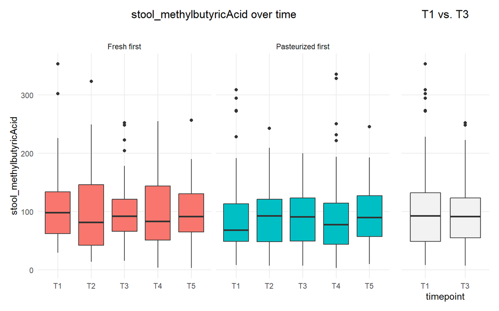

```r
plot_variable(dat, "stool_methylbutyricAcid", cut_extremeValues = FALSE)
```

## Model comparison

Share of deviance explained (including p-values for testing the respective interaction model against the model without interaction):

```r
outputList_methylbutyric_acid2 <- compare_models("stool_methylbutyricAcid")

outputList_methylbutyric_acid2$tab_explainedDeviances %>% kable() %>% kable_styling()
```

| Model | Gaussian | Gaussian (log trafo) | Gamma |
| --- | --- | --- | --- |
| Raw intervention effect | 51.1% | 57.8% | 53.3% |
| Intervention effect by gender | 51.3% (p = 0.5396) | 58.3% (p = 0.2008) | 53.9% (p = 0.1582) |
| Intervention effect by age group | 51.2% (p = 0.77) | 57.8% (p = 0.8339) | 53.3% (p = 0.8415) |
| Intervention effect by BMI group | 51.1% (p = 0.9999) | 57.9% (p = 0.79) | 53.2% (p = 0.9999) |
| Intervention effect by fiber group | 51.2% (p = 0.8175) | 57.9% (p = 0.7814) | 53.5% (p = 0.5323) |
| Intervention effect by baseline diversity | 51% (p = 0.9999) | 57.8% (p = 0.9999) | 53.3% (p = 0.8166) |

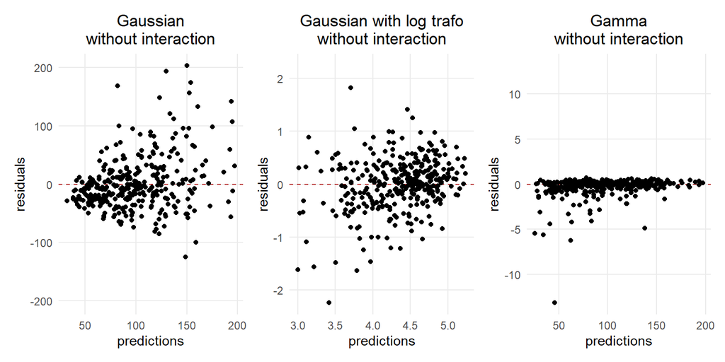

```r
outputList_methylbutyric_acid2$gg_residuals
```

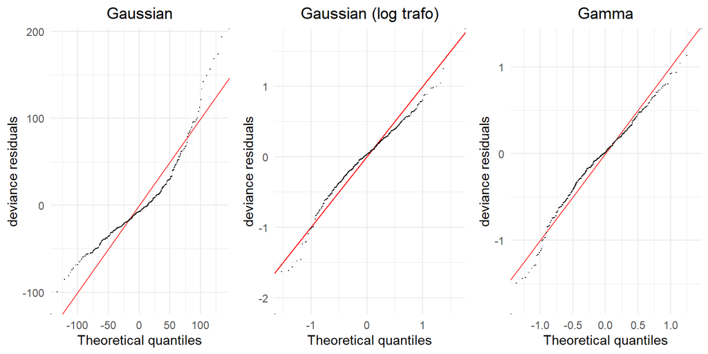

```r
mgcViz::gridPrint(outputList_methylbutyric_acid2$qq_gaussian, outputList_methylbutyric_acid2$qq_gaussianLog, outputList_methylbutyric_acid2$qq_gamma, nrow = 1)
```

## Final model (log Gaussian)

##### Estimated effects

```r
m_methylbutyric_acid2        <- outputList_methylbutyric_acid2$model_gaussianLog

APCtools:::extract_summary_linearEffects(m_methylbutyric_acid2) %>%
  mutate(coef_exp = exp(coef),
         se_exp   = exp(se),
         CI_lower_exp = exp(CI_lower),
         CI_upper_exp = exp(CI_upper),
         pvalue       = case_when(param == "(Intercept)" ~ "-",
                                  TRUE                   ~ pvalue %>% round(4) %>% as.character()),
         across(!contains("param") & !contains("pvalue"), function(x) { round(x, 3) })) %>%
  select(!contains("pvalue"), pvalue) %>%
  kable() %>%
  kable_styling()
```

| param | coef | se | CI_lower | CI_upper | coef_exp | se_exp | CI_lower_exp | CI_upper_exp | pvalue |
| --- | --- | --- | --- | --- | --- | --- | --- | --- | --- |
| (Intercept) | 4.282 | 0.109 | 4.068 | 4.497 | 72.405 | 1.116 | 58.440 | 89.707 | - |
| interventionFresh | -0.092 | 0.074 | -0.237 | 0.052 | 0.912 | 1.077 | 0.789 | 1.054 | 0.2122 |
| interventionPasteurized | -0.076 | 0.074 | -0.221 | 0.070 | 0.927 | 1.077 | 0.802 | 1.072 | 0.3087 |
| phasephase 2 | -0.028 | 0.061 | -0.147 | 0.091 | 0.972 | 1.063 | 0.863 | 1.095 | 0.6419 |
| genderW | 0.204 | 0.137 | -0.064 | 0.472 | 1.226 | 1.147 | 0.938 | 1.603 | 0.1377 |
| age_centered50 | 0.000 | 0.005 | -0.010 | 0.009 | 1.000 | 1.005 | 0.991 | 1.009 | 0.9526 |
| bmi_centered25 | -0.002 | 0.023 | -0.048 | 0.044 | 0.998 | 1.024 | 0.953 | 1.045 | 0.9182 |

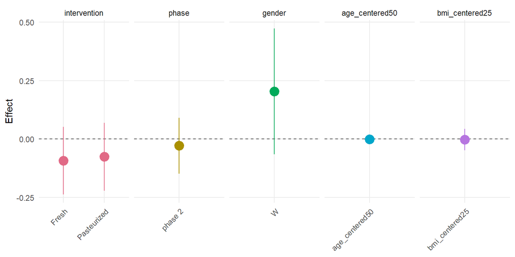

```r
APCtools::plot_linearEffects(m_methylbutyric_acid2)
```

```r
# save the interaction models for later use for visualization
m_methylbutyric_acid2_sexInt            <- outputList_methylbutyric_acid2$model_gaussianLog_sexInt
m_methylbutyric_acid2_sexInt_changedRef <- outputList_methylbutyric_acid2$model_gaussianLog_sexInt_changedRef
m_methylbutyric_acid2_ageInt            <- outputList_methylbutyric_acid2$model_gaussianLog_ageInt
m_methylbutyric_acid2_ageInt_changedRef <- outputList_methylbutyric_acid2$model_gaussianLog_ageInt_changedRef
m_methylbutyric_acid2_bmiInt            <- outputList_methylbutyric_acid2$model_gaussianLog_bmiInt
m_methylbutyric_acid2_bmiInt_changedRef <- outputList_methylbutyric_acid2$model_gaussianLog_bmiInt_changedRef
m_methylbutyric_acid2_fibInt            <- outputList_methylbutyric_acid2$model_gaussianLog_fibInt
m_methylbutyric_acid2_fibInt_changedRef <- outputList_methylbutyric_acid2$model_gaussianLog_fibInt_changedRef
m_methylbutyric_acid2_divInt            <- outputList_methylbutyric_acid2$model_gaussianLog_divInt
m_methylbutyric_acid2_divInt_changedRef <- outputList_methylbutyric_acid2$model_gaussianLog_divInt_changedRef
```

# SCRF - Acetic acid

## Sensitivity analysis results

All below results were estimated on the observed data, without specific outlier exclusion / handling. To check the influence of outliers on the results, the below models were re-estimated on the dataset in which outliers (= points above the threshold ‘mean + 3*sd’) were trimmed to the treshold ’mean + 3*sd’. These sensitivity results are not comprised in this document. The results based on the trimmed data were not substantially different from the original results.

```r
# # trim outliers to mean + 3*sd
# upper_threshold <- median(dat$stool_aceticAcid) + 3*sd(dat$stool_aceticAcid)
#
# dat <- dat %>%
#   mutate(stool_aceticAcid_trimmed = case_when(stool_aceticAcid < upper_threshold ~ stool_aceticAcid,
#                                               TRUE                               ~ upper_threshold))
# dat_model <- dat_model %>%
#   mutate(stool_aceticAcid_trimmed = case_when(stool_aceticAcid < upper_threshold ~ stool_aceticAcid,
#                                               TRUE                               ~ upper_threshold))
```

## Description

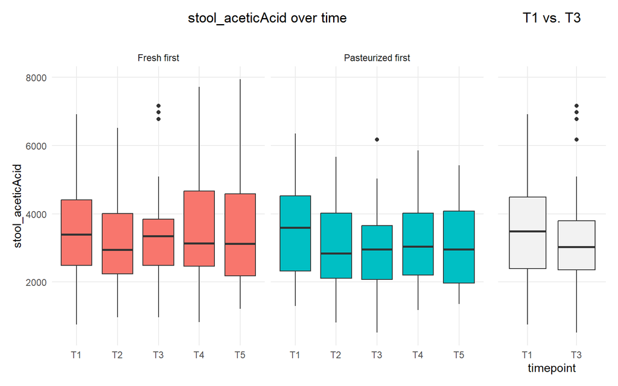

```r
plot_variable(dat, "stool_aceticAcid", cut_extremeValues = FALSE)
```

## Model comparison

Share of deviance explained (including p-values for testing the respective interaction model against the model without interaction):

```r
outputList_acetic_acid <- compare_models("stool_aceticAcid")

outputList_acetic_acid$tab_explainedDeviances %>% kable() %>% kable_styling()
```

| Model | Gaussian | Gaussian (log trafo) | Gamma |
| --- | --- | --- | --- |
| Raw intervention effect | 52.6% | 55.2% | 52% |
| Intervention effect by gender | 53% (p = 0.2862) | 55.5% (p = 0.4501) | 52.4% (p = 0.3397) |
| Intervention effect by age group | 52.6% (p = 0.8066) | 55.3% (p = 0.7414) | 52.1% (p = 0.8643) |
| Intervention effect by BMI group | 52.9% (p = 0.3697) | 55.7% (p = 0.2841) | 52.5% (p = 0.256) |
| Intervention effect by fiber group | 52.7% (p = 0.7818) | 55.3% (p = 0.7361) | 52.1% (p = 0.8339) |
| Intervention effect by baseline diversity | 54% (p = 0.0172) | 56.3% (p = 0.0424) | 53.4% (p = 0.0192) |

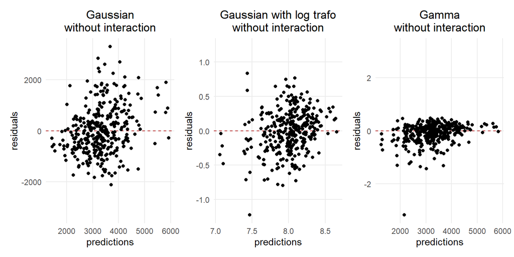

```r
outputList_acetic_acid$gg_residuals
```

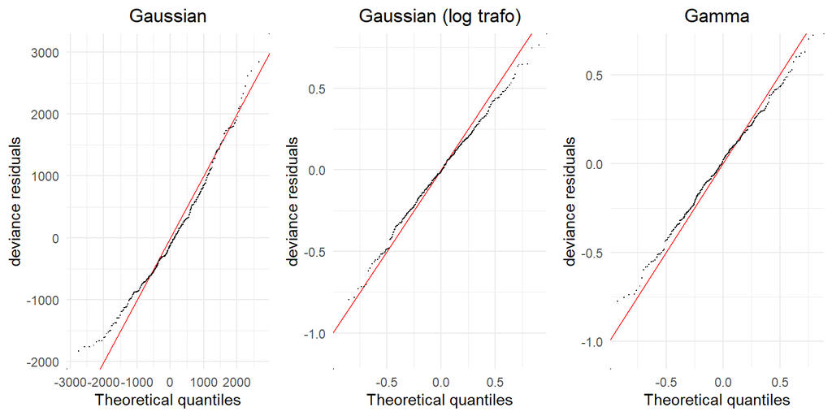

```r
mgcViz::gridPrint(outputList_acetic_acid$qq_gaussian, outputList_acetic_acid$qq_gaussianLog, outputList_acetic_acid$qq_gamma, nrow = 1)
```

## Final model (Gamma)

##### Estimated effects

```r
m_acetic_acid        <- outputList_acetic_acid$model_gamma

APCtools:::extract_summary_linearEffects(m_acetic_acid) %>%
  mutate(coef_exp = exp(coef),
         se_exp   = exp(se),
         CI_lower_exp = exp(CI_lower),
         CI_upper_exp = exp(CI_upper),
         pvalue       = case_when(param == "(Intercept)" ~ "-",
                                  TRUE                   ~ pvalue %>% round(4) %>% as.character()),
         across(!contains("param") & !contains("pvalue"), function(x) { round(x, 3) })) %>%
  select(!contains("pvalue"), pvalue) %>%
  kable() %>%
  kable_styling()
```

| param | coef | se | CI_lower | CI_upper | coef_exp | se_exp | CI_lower_exp | CI_upper_exp | pvalue |
| --- | --- | --- | --- | --- | --- | --- | --- | --- | --- |
| (Intercept) | 8.125 | 0.059 | 8.009 | 8.242 | 3378.739 | 1.061 | 3006.994 | 3796.442 | - |
| interventionFresh | -0.029 | 0.043 | -0.112 | 0.055 | 0.972 | 1.044 | 0.894 | 1.057 | 0.5034 |
| interventionPasteurized | -0.022 | 0.043 | -0.106 | 0.062 | 0.978 | 1.044 | 0.899 | 1.064 | 0.6106 |
| phasephase 2 | -0.014 | 0.035 | -0.083 | 0.055 | 0.986 | 1.036 | 0.921 | 1.057 | 0.6955 |
| genderW | -0.107 | 0.074 | -0.251 | 0.037 | 0.898 | 1.076 | 0.778 | 1.038 | 0.1463 |
| age_centered50 | -0.004 | 0.003 | -0.009 | 0.001 | 0.996 | 1.003 | 0.991 | 1.001 | 0.1292 |
| bmi_centered25 | 0.009 | 0.013 | -0.016 | 0.034 | 1.009 | 1.013 | 0.985 | 1.034 | 0.4695 |

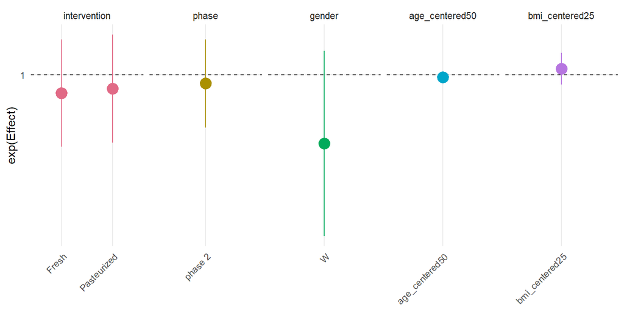

```r
APCtools::plot_linearEffects(m_acetic_acid)
```

```r
# save the interaction models for later use for visualization
m_acetic_acid_sexInt            <- outputList_acetic_acid$model_gamma_sexInt
m_acetic_acid_sexInt_changedRef <- outputList_acetic_acid$model_gamma_sexInt_changedRef
m_acetic_acid_ageInt            <- outputList_acetic_acid$model_gamma_ageInt
m_acetic_acid_ageInt_changedRef <- outputList_acetic_acid$model_gamma_ageInt_changedRef
m_acetic_acid_bmiInt            <- outputList_acetic_acid$model_gamma_bmiInt
m_acetic_acid_bmiInt_changedRef <- outputList_acetic_acid$model_gamma_bmiInt_changedRef
m_acetic_acid_fibInt            <- outputList_acetic_acid$model_gamma_fibInt
m_acetic_acid_fibInt_changedRef <- outputList_acetic_acid$model_gamma_fibInt_changedRef
m_acetic_acid_divInt            <- outputList_acetic_acid$model_gamma_divInt
m_acetic_acid_divInt_changedRef <- outputList_acetic_acid$model_gamma_divInt_changedRef
```

# SCRF - Butyric acid

## Sensitivity analysis results

All below results were estimated on the observed data, without specific outlier exclusion / handling. To check the influence of outliers on the results, the below models were re-estimated on the dataset in which outliers (= points above the threshold ‘mean + 3*sd’) were trimmed to the treshold ’mean + 3*sd’. These sensitivity results are not comprised in this document. The results based on the trimmed data were not substantially different from the original results.

```r
# # trim outliers to mean + 3*sd
# upper_threshold <- median(dat$stool_butyricAcid) + 3*sd(dat$stool_butyricAcid)
#
# dat <- dat %>%
#   mutate(stool_butyricAcid_trimmed = case_when(stool_butyricAcid < upper_threshold ~ stool_butyricAcid,
#                                                TRUE                               ~ upper_threshold))
# dat_model <- dat_model %>%
#   mutate(stool_butyricAcid_trimmed = case_when(stool_butyricAcid < upper_threshold ~ stool_butyricAcid,
#                                                TRUE                               ~ upper_threshold))
```

## Description

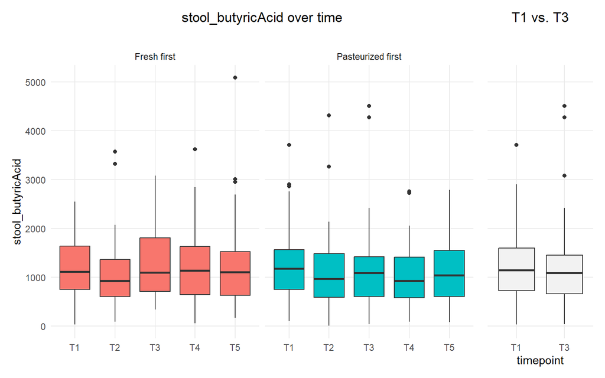

```r
plot_variable(dat, "stool_butyricAcid", cut_extremeValues = FALSE)
```

## Model comparison

Share of deviance explained (including p-values for testing the respective interaction model against the model without interaction):

```r
outputList_butyric_acid <- compare_models("stool_butyricAcid")

outputList_butyric_acid$tab_explainedDeviances %>% kable() %>% kable_styling()
```

| Model | Gaussian | Gaussian (log trafo) | Gamma |
| --- | --- | --- | --- |
| Raw intervention effect | 59.8% | 61.5% | 51.1% |
| Intervention effect by gender | 60.1% (p = 0.3474) | 61.9% (p = 0.2618) | 51.6% (p = 0.1961) |
| Intervention effect by age group | 59.9% (p = 0.867) | 61.5% (p = 0.9999) | 51.1% (p = 0.9999) |
| Intervention effect by BMI group | 60.1% (p = 0.4643) | 61.7% (p = 0.6351) | 51.5% (p = 0.3191) |
| Intervention effect by fiber group | 60.2% (p = 0.3014) | 61.6% (p = 0.7807) | 51.3% (p = 0.4717) |
| Intervention effect by baseline diversity | 60.3% (p = 0.1804) | 62.1% (p = 0.1507) | 52.3% (p = 0.0222) |

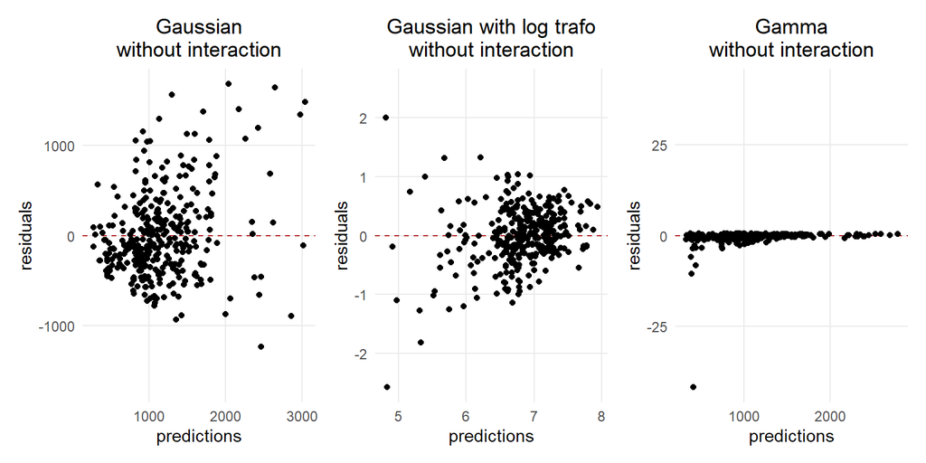

```r
outputList_butyric_acid$gg_residuals
```

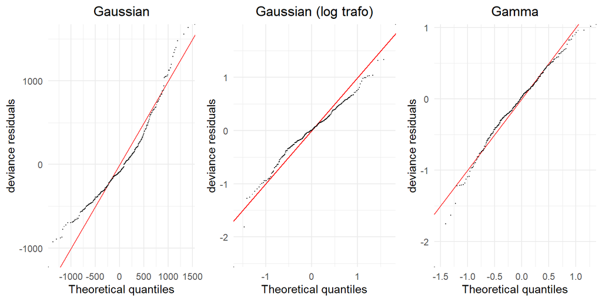

```r
mgcViz::gridPrint(outputList_butyric_acid$qq_gaussian, outputList_butyric_acid$qq_gaussianLog, outputList_butyric_acid$qq_gamma, nrow = 1)
```

## Final model (Gamma)

##### Estimated effects

```r
m_butyric_acid        <- outputList_butyric_acid$model_gamma

APCtools:::extract_summary_linearEffects(m_butyric_acid) %>%
  mutate(coef_exp = exp(coef),
         se_exp   = exp(se),
         CI_lower_exp = exp(CI_lower),
         CI_upper_exp = exp(CI_upper),
         pvalue       = case_when(param == "(Intercept)" ~ "-",
                                  TRUE                   ~ pvalue %>% round(4) %>% as.character()),
         across(!contains("param") & !contains("pvalue"), function(x) { round(x, 3) })) %>%
  select(!contains("pvalue"), pvalue) %>%
  kable() %>%
  kable_styling()
```

| param | coef | se | CI_lower | CI_upper | coef_exp | se_exp | CI_lower_exp | CI_upper_exp | pvalue |
| --- | --- | --- | --- | --- | --- | --- | --- | --- | --- |
| (Intercept) | 7.042 | 0.088 | 6.870 | 7.214 | 1144.011 | 1.092 | 963.321 | 1358.592 | - |
| interventionFresh | -0.154 | 0.064 | -0.281 | -0.028 | 0.857 | 1.067 | 0.755 | 0.972 | 0.0173 |
| interventionPasteurized | -0.039 | 0.065 | -0.166 | 0.088 | 0.962 | 1.067 | 0.847 | 1.092 | 0.5501 |
| phasephase 2 | 0.033 | 0.053 | -0.071 | 0.137 | 1.033 | 1.054 | 0.931 | 1.146 | 0.5385 |
| genderW | -0.187 | 0.108 | -0.399 | 0.024 | 0.829 | 1.114 | 0.671 | 1.024 | 0.0837 |
| age_centered50 | -0.010 | 0.004 | -0.017 | -0.003 | 0.990 | 1.004 | 0.983 | 0.997 | 0.0068 |
| bmi_centered25 | 0.022 | 0.019 | -0.014 | 0.058 | 1.022 | 1.019 | 0.986 | 1.060 | 0.2349 |

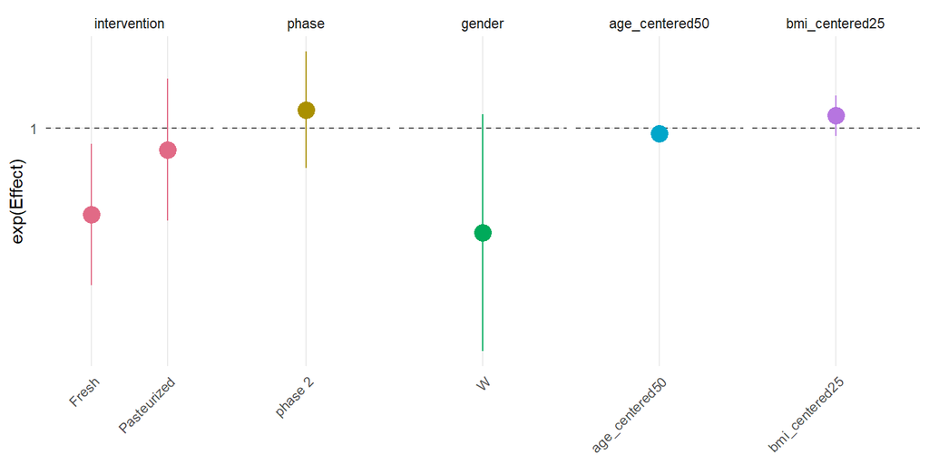

```r
APCtools::plot_linearEffects(m_butyric_acid)
```

```r
# save the interaction models for later use for visualization
m_butyric_acid_sexInt            <- outputList_butyric_acid$model_gamma_sexInt
m_butyric_acid_sexInt_changedRef <- outputList_butyric_acid$model_gamma_sexInt_changedRef
m_butyric_acid_ageInt            <- outputList_butyric_acid$model_gamma_ageInt
m_butyric_acid_ageInt_changedRef <- outputList_butyric_acid$model_gamma_ageInt_changedRef
m_butyric_acid_bmiInt            <- outputList_butyric_acid$model_gamma_bmiInt
m_butyric_acid_bmiInt_changedRef <- outputList_butyric_acid$model_gamma_bmiInt_changedRef
m_butyric_acid_fibInt            <- outputList_butyric_acid$model_gamma_fibInt
m_butyric_acid_fibInt_changedRef <- outputList_butyric_acid$model_gamma_fibInt_changedRef
m_butyric_acid_divInt            <- outputList_butyric_acid$model_gamma_divInt
m_butyric_acid_divInt_changedRef <- outputList_butyric_acid$model_gamma_divInt_changedRef
```

# SCRF - Hexanoic acid

## Sensitivity analysis results

All below results were estimated on the observed data, without specific outlier exclusion / handling. To check the influence of outliers on the results, the below models were re-estimated on the dataset in which outliers (= points above the threshold ‘mean + 3*sd’) were trimmed to the treshold ’mean + 3*sd’. These sensitivity results are not comprised in this document. The results based on the trimmed data were not substantially different from the original results.

```r
# # trim outliers to mean + 3*sd
# upper_threshold <- median(dat$stool_hexanoicAcid) + 3*sd(dat$stool_hexanoicAcid)
#
# dat <- dat %>%
#   mutate(stool_hexanoicAcid_trimmed = case_when(stool_hexanoicAcid < upper_threshold ~ stool_hexanoicAcid,
#                                                 TRUE                               ~ upper_threshold))
# dat_model <- dat_model %>%
#   mutate(stool_hexanoicAcid_trimmed = case_when(stool_hexanoicAcid < upper_threshold ~ stool_hexanoicAcid,
#                                                 TRUE                               ~ upper_threshold))
```

## Description

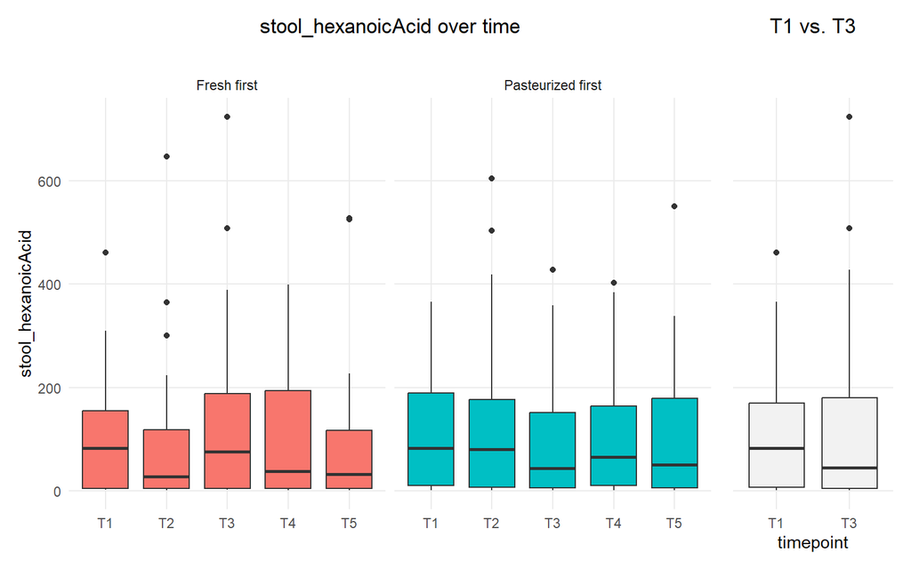

```r
plot_variable(dat, "stool_hexanoicAcid", cut_extremeValues = FALSE)
```

## Model comparison

Share of deviance explained (including p-values for testing the respective interaction model against the model without interaction):

```r
outputList_hexanoic_acid <- compare_models("stool_hexanoicAcid")

outputList_hexanoic_acid$tab_explainedDeviances %>% kable() %>% kable_styling()
```

| Model | Gaussian | Gaussian (log trafo) | Gamma |
| --- | --- | --- | --- |
| Raw intervention effect | 67.6% | 86.5% | 81.2% |
| Intervention effect by gender | 68% (p = 0.2176) | 86.6% (p = 0.3701) | 81.3% (p = 0.6383) |
| Intervention effect by age group | 67.8% (p = 0.5164) | 86.6% (p = 0.6588) | 81.3% (p = 0.3852) |
| Intervention effect by BMI group | 67.8% (p = 0.5604) | 86.6% (p = 0.3561) | 81.4% (p = 0.2802) |
| Intervention effect by fiber group | 67.8% (p = 0.4953) | 86.5% (p = 0.8243) | 81.2% (p = 0.9063) |
| Intervention effect by baseline diversity | 67.5% (p = 0.9999) | 86.7% (p = 0.2524) | 81.5% (p = 0.1212) |

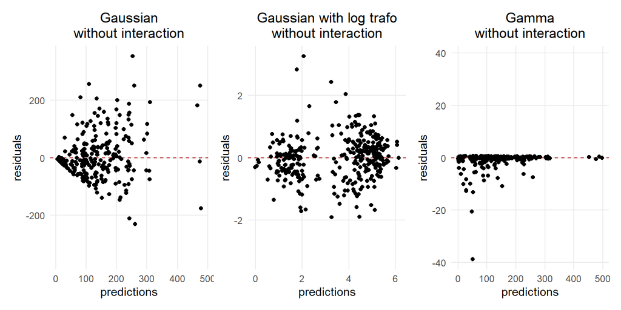

```r
outputList_hexanoic_acid$gg_residuals
```

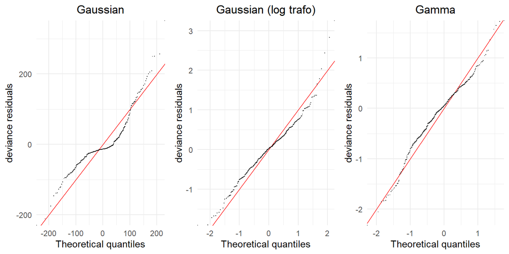

```r
mgcViz::gridPrint(outputList_hexanoic_acid$qq_gaussian, outputList_hexanoic_acid$qq_gaussianLog, outputList_hexanoic_acid$qq_gamma, nrow = 1)
```

## Final model (Gaussian)

##### Estimated effects

```r
m_hexanoic_acid        <- outputList_hexanoic_acid$model_gaussian

APCtools:::extract_summary_linearEffects(m_hexanoic_acid) %>%
  mutate(pvalue       = case_when(param == "(Intercept)" ~ "-",
                                  TRUE                   ~ pvalue %>% round(4) %>% as.character()),
         across(!contains("param") & !contains("pvalue"), function(x) { round(x, 3) })) %>%
  select(!contains("pvalue"), pvalue) %>%
  kable() %>%
  kable_styling()
```

| param | coef | se | CI_lower | CI_upper | pvalue |
| --- | --- | --- | --- | --- | --- |
| (Intercept) | 77.545 | 18.332 | 41.615 | 113.474 | - |
| interventionFresh | -8.032 | 10.583 | -28.775 | 12.711 | 0.4486 |
| interventionPasteurized | 2.887 | 10.625 | -17.937 | 23.711 | 0.786 |
| phasephase 2 | 0.658 | 8.713 | -16.419 | 17.735 | 0.9398 |
| genderW | 47.022 | 23.472 | 1.018 | 93.027 | 0.0462 |
| age_centered50 | -0.512 | 0.808 | -2.095 | 1.071 | 0.5268 |
| bmi_centered25 | 0.711 | 4.023 | -7.174 | 8.595 | 0.8599 |

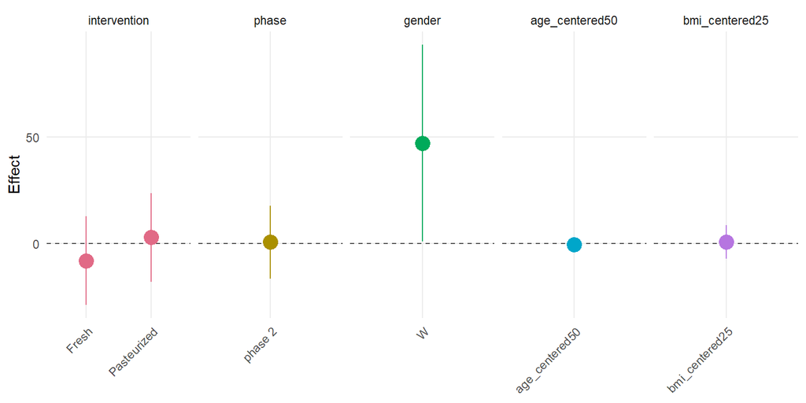

```r
APCtools::plot_linearEffects(m_hexanoic_acid)
```

```r
# save the interaction models for later use for visualization
m_hexanoic_acid_sexInt            <- outputList_hexanoic_acid$model_gaussian_sexInt
m_hexanoic_acid_sexInt_changedRef <- outputList_hexanoic_acid$model_gaussian_sexInt_changedRef
m_hexanoic_acid_ageInt            <- outputList_hexanoic_acid$model_gaussian_ageInt
m_hexanoic_acid_ageInt_changedRef <- outputList_hexanoic_acid$model_gaussian_ageInt_changedRef
m_hexanoic_acid_bmiInt            <- outputList_hexanoic_acid$model_gaussian_bmiInt
m_hexanoic_acid_bmiInt_changedRef <- outputList_hexanoic_acid$model_gaussian_bmiInt_changedRef
m_hexanoic_acid_fibInt            <- outputList_hexanoic_acid$model_gaussian_fibInt
m_hexanoic_acid_fibInt_changedRef <- outputList_hexanoic_acid$model_gaussian_fibInt_changedRef
m_hexanoic_acid_divInt            <- outputList_hexanoic_acid$model_gaussian_divInt
m_hexanoic_acid_divInt_changedRef <- outputList_hexanoic_acid$model_gaussian_divInt_changedRef
```

# SCRF - Isobutyric acid

## Description

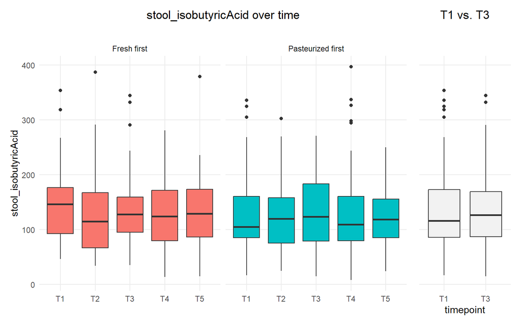

```r
plot_variable(dat, "stool_isobutyricAcid", cut_extremeValues = FALSE)
```

## Model comparison

Share of deviance explained (including p-values for testing the respective interaction model against the model without interaction):

```r
outputList_isobutyric_acid <- compare_models("stool_isobutyricAcid")

outputList_isobutyric_acid$tab_explainedDeviances %>% kable() %>% kable_styling()
```

| Model | Gaussian | Gaussian (log trafo) | Gamma |
| --- | --- | --- | --- |
| Raw intervention effect | 50.4% | 54% | 50.1% |
| Intervention effect by gender | 50.6% (p = 0.6035) | 54.4% (p = 0.3463) | 50.5% (p = 0.3091) |
| Intervention effect by age group | 50.6% (p = 0.6254) | 54.2% (p = 0.6724) | 50.3% (p = 0.6239) |
| Intervention effect by BMI group | 50.5% (p = 0.7865) | 54.1% (p = 0.8555) | 50.1% (p = 0.9999) |
| Intervention effect by fiber group | 50.5% (p = 0.8305) | 54.1% (p = 0.8917) | 50.2% (p = 0.7455) |
| Intervention effect by baseline diversity | 50.4% (p = 0.9999) | 53.9% (p = 0.9999) | 50.2% (p = 0.8373) |

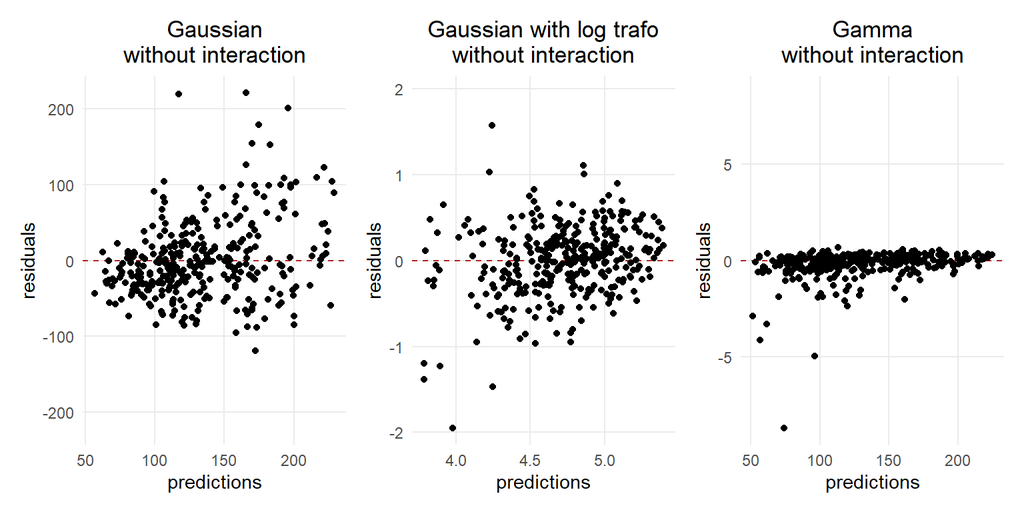

```r
outputList_isobutyric_acid$gg_residuals
```

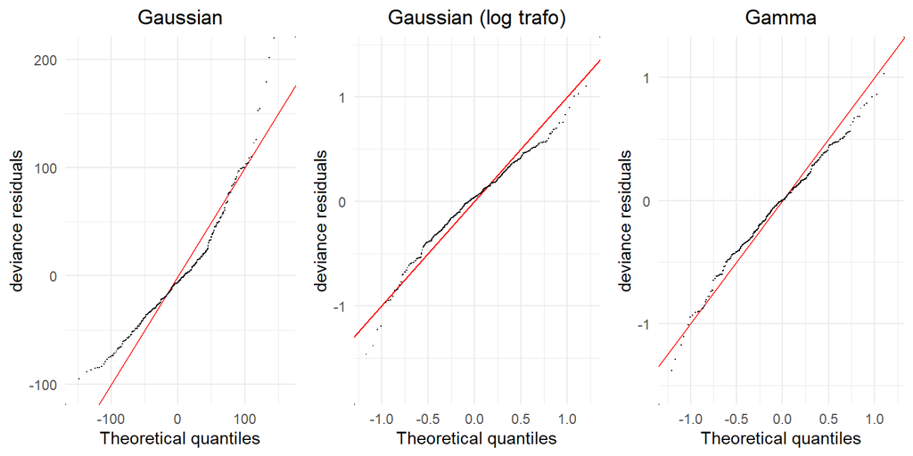

```r
mgcViz::gridPrint(outputList_isobutyric_acid$qq_gaussian, outputList_isobutyric_acid$qq_gaussianLog, outputList_isobutyric_acid$qq_gamma, nrow = 1)
```

## Final model (Gamma)

##### Estimated effects

```r
m_isobutyric_acid        <- outputList_isobutyric_acid$model_gamma

APCtools:::extract_summary_linearEffects(m_isobutyric_acid) %>%
  mutate(coef_exp = exp(coef),
         se_exp   = exp(se),
         CI_lower_exp = exp(CI_lower),
         CI_upper_exp = exp(CI_upper),
         pvalue       = case_when(param == "(Intercept)" ~ "-",
                                  TRUE                   ~ pvalue %>% round(4) %>% as.character()),
         across(!contains("param") & !contains("pvalue"), function(x) { round(x, 3) })) %>%
  select(!contains("pvalue"), pvalue) %>%
  kable() %>%
  kable_styling()
```

| param | coef | se | CI_lower | CI_upper | coef_exp | se_exp | CI_lower_exp | CI_upper_exp | pvalue |
| --- | --- | --- | --- | --- | --- | --- | --- | --- | --- |
| (Intercept) | 4.788 | 0.078 | 4.635 | 4.941 | 120.034 | 1.081 | 102.996 | 139.892 | - |
| interventionFresh | -0.045 | 0.056 | -0.155 | 0.066 | 0.956 | 1.058 | 0.856 | 1.068 | 0.4292 |
| interventionPasteurized | -0.069 | 0.057 | -0.180 | 0.042 | 0.933 | 1.058 | 0.835 | 1.043 | 0.2226 |
| phasephase 2 | -0.014 | 0.046 | -0.105 | 0.077 | 0.987 | 1.048 | 0.901 | 1.081 | 0.7704 |
| genderW | 0.083 | 0.096 | -0.106 | 0.272 | 1.086 | 1.101 | 0.899 | 1.313 | 0.3912 |
| age_centered50 | -0.002 | 0.003 | -0.008 | 0.005 | 0.998 | 1.003 | 0.992 | 1.005 | 0.5566 |
| bmi_centered25 | 0.002 | 0.017 | -0.030 | 0.034 | 1.002 | 1.017 | 0.970 | 1.035 | 0.9038 |

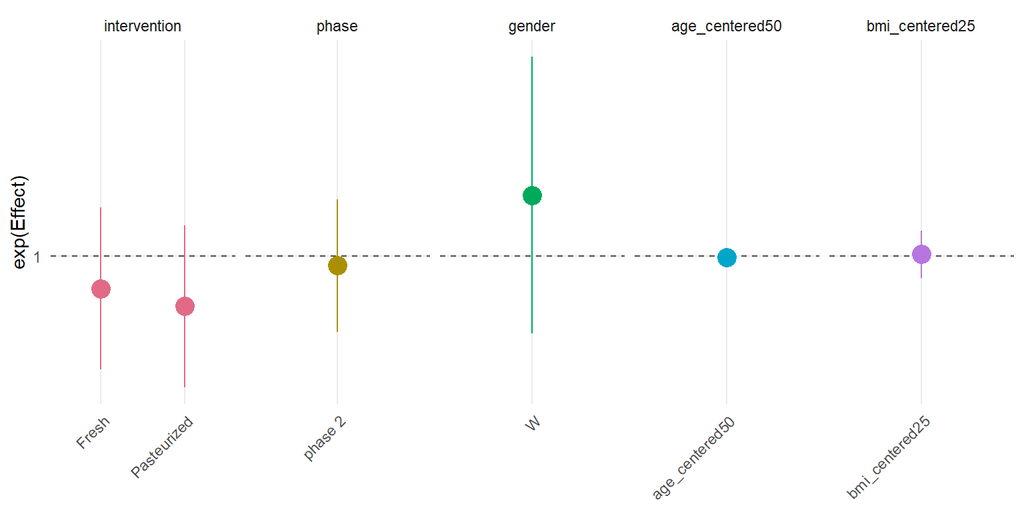

```r
APCtools::plot_linearEffects(m_isobutyric_acid)
```

```r
# save the interaction models for later use for visualization
m_isobutyric_acid_sexInt            <- outputList_isobutyric_acid$model_gamma_sexInt
m_isobutyric_acid_sexInt_changedRef <- outputList_isobutyric_acid$model_gamma_sexInt_changedRef
m_isobutyric_acid_ageInt            <- outputList_isobutyric_acid$model_gamma_ageInt
m_isobutyric_acid_ageInt_changedRef <- outputList_isobutyric_acid$model_gamma_ageInt_changedRef
m_isobutyric_acid_bmiInt            <- outputList_isobutyric_acid$model_gamma_bmiInt
m_isobutyric_acid_bmiInt_changedRef <- outputList_isobutyric_acid$model_gamma_bmiInt_changedRef
m_isobutyric_acid_fibInt            <- outputList_isobutyric_acid$model_gamma_fibInt
m_isobutyric_acid_fibInt_changedRef <- outputList_isobutyric_acid$model_gamma_fibInt_changedRef
m_isobutyric_acid_divInt            <- outputList_isobutyric_acid$model_gamma_divInt
m_isobutyric_acid_divInt_changedRef <- outputList_isobutyric_acid$model_gamma_divInt_changedRef
```

# SCRF - Isovaleric acid

## Sensitivity analysis results

All below results were estimated on the observed data, without specific outlier exclusion / handling. To check the influence of outliers on the results, the below models were re-estimated on the dataset in which outliers (= points above the threshold ‘mean + 3*sd’) were trimmed to the treshold ’mean + 3*sd’. These sensitivity results are not comprised in this document. The results based on the trimmed data were not substantially different from the original results.

```r
# # trim outliers to mean + 3*sd
# upper_threshold <- median(dat$stool_isovalericAcid) + 3*sd(dat$stool_isovalericAcid)
#
# dat <- dat %>%
#   mutate(stool_isovalericAcid_trimmed = case_when(stool_isovalericAcid < upper_threshold ~ stool_isovalericAcid,
#                                                   TRUE                               ~ upper_threshold))
# dat_model <- dat_model %>%
#   mutate(stool_isovalericAcid_trimmed = case_when(stool_isovalericAcid < upper_threshold ~ stool_isovalericAcid,
#                                                   TRUE                               ~ upper_threshold))
```

## Description

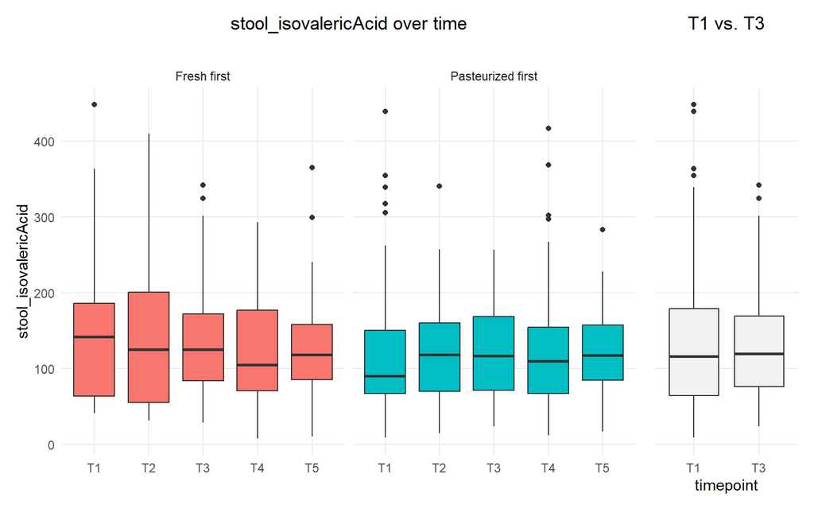

```r
plot_variable(dat, "stool_isovalericAcid", cut_extremeValues = FALSE)
```

## Model comparison

Share of deviance explained (including p-values for testing the respective interaction model against the model without interaction):

```r
outputList_isovaleric_acid <- compare_models("stool_isovalericAcid")

outputList_isovaleric_acid$tab_explainedDeviances %>% kable() %>% kable_styling()
```

| Model | Gaussian | Gaussian (log trafo) | Gamma |
| --- | --- | --- | --- |
| Raw intervention effect | 53% | 57.8% | 54.2% |
| Intervention effect by gender | 53.2% (p = 0.5321) | 58.2% (p = 0.2645) | 54.6% (p = 0.2334) |
| Intervention effect by age group | 53.1% (p = 0.8536) | 57.9% (p = 0.76) | 54.3% (p = 0.6924) |
| Intervention effect by BMI group | 52.9% (p = 0.9999) | 57.9% (p = 0.8221) | 54.1% (p = 0.9999) |
| Intervention effect by fiber group | 53.1% (p = 0.8697) | 57.8% (p = 0.972) | 54.2% (p = 0.7788) |
| Intervention effect by baseline diversity | 52.9% (p = 0.9999) | 57.8% (p = 0.9999) | 54.2% (p = 0.9955) |

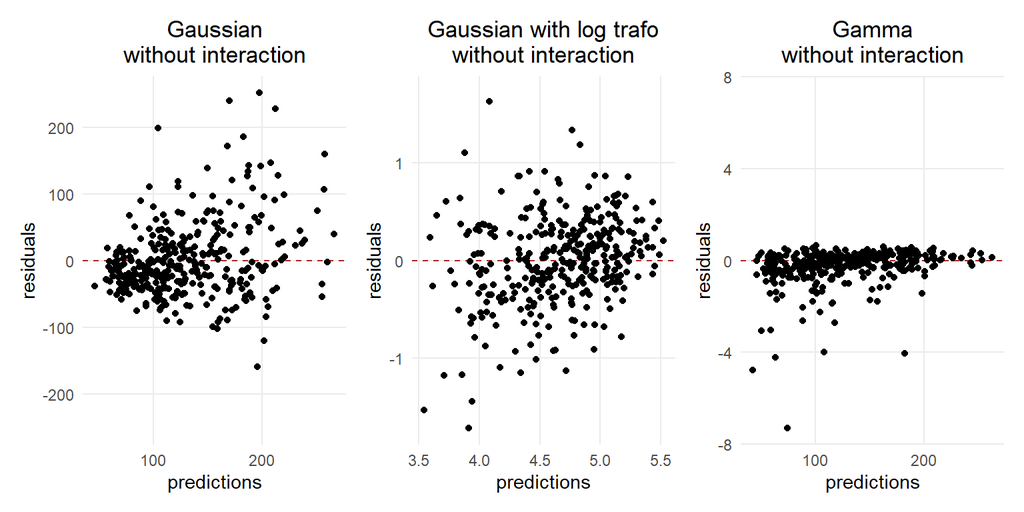

```r
outputList_isovaleric_acid$gg_residuals
```

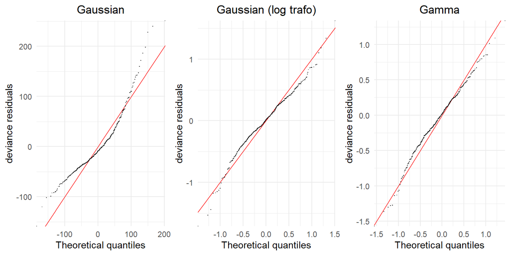

```r
mgcViz::gridPrint(outputList_isovaleric_acid$qq_gaussian, outputList_isovaleric_acid$qq_gaussianLog, outputList_isovaleric_acid$qq_gamma, nrow = 1)
```

## Final model (Gamma)

##### Estimated effects

```r
m_isovaleric_acid        <- outputList_isovaleric_acid$model_gamma

APCtools:::extract_summary_linearEffects(m_isovaleric_acid) %>%
  mutate(coef_exp = exp(coef),
         se_exp   = exp(se),
         CI_lower_exp = exp(CI_lower),
         CI_upper_exp = exp(CI_upper),
         pvalue       = case_when(param == "(Intercept)" ~ "-",
                                  TRUE                   ~ pvalue %>% round(4) %>% as.character()),
         across(!contains("param") & !contains("pvalue"), function(x) { round(x, 3) })) %>%
  select(!contains("pvalue"), pvalue) %>%
  kable() %>%
  kable_styling()
```

| param | coef | se | CI_lower | CI_upper | coef_exp | se_exp | CI_lower_exp | CI_upper_exp | pvalue |
| --- | --- | --- | --- | --- | --- | --- | --- | --- | --- |
| (Intercept) | 4.737 | 0.093 | 4.555 | 4.919 | 114.079 | 1.097 | 95.128 | 136.805 | - |
| interventionFresh | -0.033 | 0.063 | -0.157 | 0.091 | 0.968 | 1.065 | 0.855 | 1.095 | 0.6021 |
| interventionPasteurized | -0.078 | 0.063 | -0.202 | 0.046 | 0.925 | 1.065 | 0.817 | 1.047 | 0.2195 |
| phasephase 2 | -0.037 | 0.052 | -0.138 | 0.065 | 0.964 | 1.053 | 0.871 | 1.067 | 0.4806 |
| genderW | 0.113 | 0.116 | -0.114 | 0.340 | 1.120 | 1.123 | 0.892 | 1.405 | 0.3304 |
| age_centered50 | -0.001 | 0.004 | -0.009 | 0.007 | 0.999 | 1.004 | 0.991 | 1.007 | 0.8454 |
| bmi_centered25 | -0.005 | 0.020 | -0.044 | 0.034 | 0.995 | 1.020 | 0.957 | 1.035 | 0.8082 |

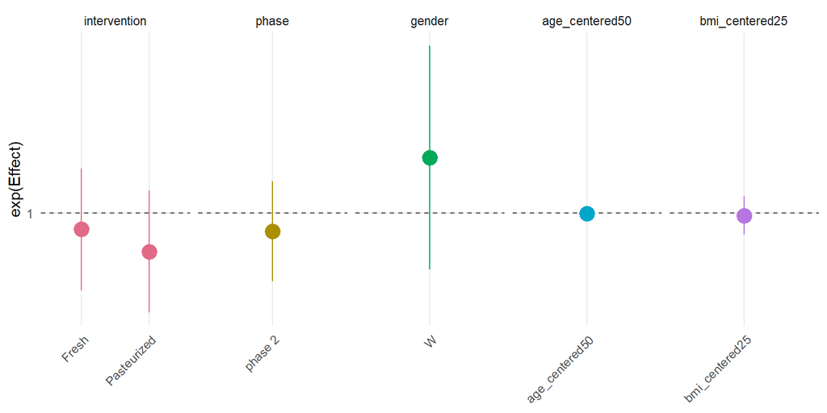

```r
APCtools::plot_linearEffects(m_isovaleric_acid)
```

```r
# save the interaction models for later use for visualization
m_isovaleric_acid_sexInt            <- outputList_isovaleric_acid$model_gamma_sexInt
m_isovaleric_acid_sexInt_changedRef <- outputList_isovaleric_acid$model_gamma_sexInt_changedRef
m_isovaleric_acid_ageInt            <- outputList_isovaleric_acid$model_gamma_ageInt
m_isovaleric_acid_ageInt_changedRef <- outputList_isovaleric_acid$model_gamma_ageInt_changedRef
m_isovaleric_acid_bmiInt            <- outputList_isovaleric_acid$model_gamma_bmiInt
m_isovaleric_acid_bmiInt_changedRef <- outputList_isovaleric_acid$model_gamma_bmiInt_changedRef
m_isovaleric_acid_fibInt            <- outputList_isovaleric_acid$model_gamma_fibInt
m_isovaleric_acid_fibInt_changedRef <- outputList_isovaleric_acid$model_gamma_fibInt_changedRef
m_isovaleric_acid_divInt            <- outputList_isovaleric_acid$model_gamma_divInt
m_isovaleric_acid_divInt_changedRef <- outputList_isovaleric_acid$model_gamma_divInt_changedRef
```

# SCRF - Propionic acid

## Sensitivity analysis results

All below results were estimated on the observed data, without specific outlier exclusion / handling. To check the influence of outliers on the results, the below models were re-estimated on the dataset in which outliers (= points above the threshold ‘mean + 3*sd’) were trimmed to the treshold ’mean + 3*sd’. These sensitivity results are not comprised in this document. The results based on the trimmed data were not substantially different from the original results.

```r
# # trim outliers to mean + 3*sd
# upper_threshold <- median(dat$stool_propionicAcid) + 3*sd(dat$stool_propionicAcid)
#
# dat <- dat %>%
#   mutate(stool_propionicAcid_trimmed = case_when(stool_propionicAcid < upper_threshold ~ stool_propionicAcid,
#                                                  TRUE                               ~ upper_threshold))
# dat_model <- dat_model %>%
#   mutate(stool_propionicAcid_trimmed = case_when(stool_propionicAcid < upper_threshold ~ stool_propionicAcid,
#                                                  TRUE                               ~ upper_threshold))
```

## Description

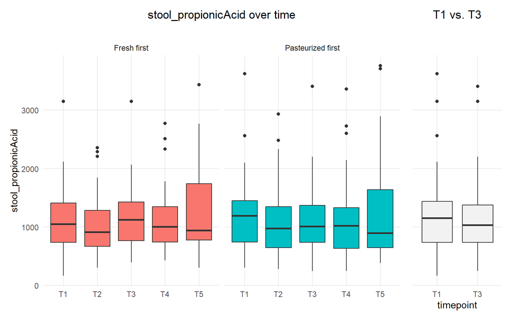

```r
plot_variable(dat, "stool_propionicAcid", cut_extremeValues = FALSE)
```

## Model comparison

Share of deviance explained (including p-values for testing the respective interaction model against the model without interaction):

```r
outputList_propionic_acid <- compare_models("stool_propionicAcid")

outputList_propionic_acid$tab_explainedDeviances %>% kable() %>% kable_styling()
```

| Model | Gaussian | Gaussian (log trafo) | Gamma |
| --- | --- | --- | --- |
| Raw intervention effect | 62.6% | 61.9% | 60.9% |
| Intervention effect by gender | 63.3% (p = 0.1028) | 62.5% (p = 0.1242) | 61.6% (p = 0.1112) |
| Intervention effect by age group | 62.8% (p = 0.533) | 62% (p = 0.6395) | 61.1% (p = 0.6671) |
| Intervention effect by BMI group | 62.8% (p = 0.5022) | 62.1% (p = 0.4896) | 61% (p = 0.7097) |
| Intervention effect by fiber group | 62.8% (p = 0.5415) | 62% (p = 0.6059) | 61.1% (p = 0.5935) |
| Intervention effect by baseline diversity | 62.9% (p = 0.3547) | 62.2% (p = 0.3504) | 61.3% (p = 0.3216) |

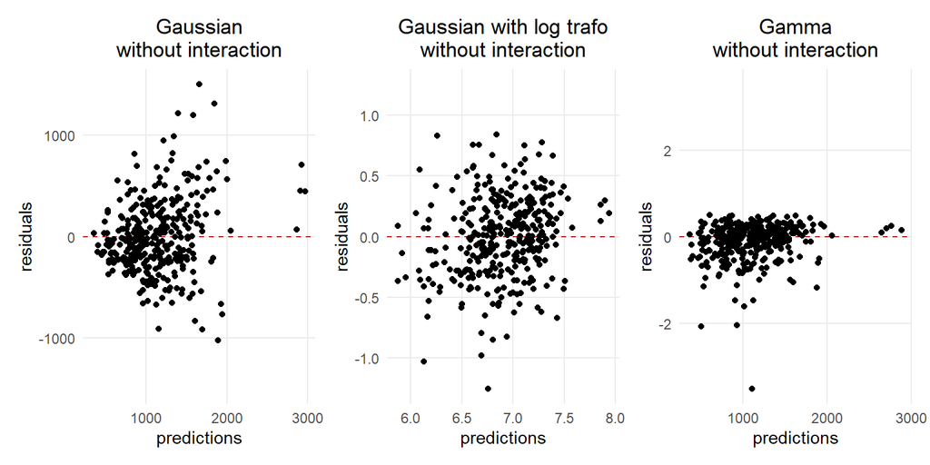

```r
outputList_propionic_acid$gg_residuals
```

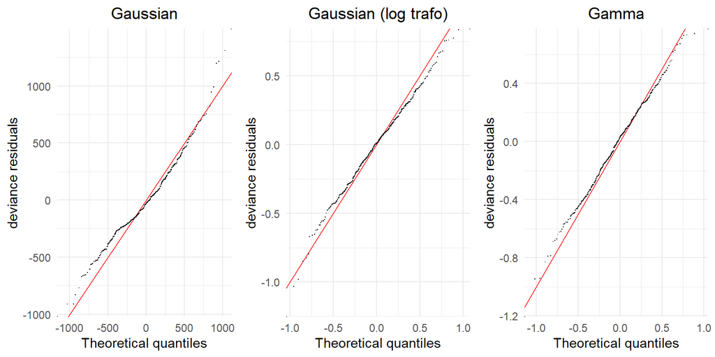

```r
mgcViz::gridPrint(outputList_propionic_acid$qq_gaussian, outputList_propionic_acid$qq_gaussianLog, outputList_propionic_acid$qq_gamma, nrow = 1)
```

## Final model (Gamma)

##### Estimated effects

```r
m_propionic_acid        <- outputList_propionic_acid$model_gamma

APCtools:::extract_summary_linearEffects(m_propionic_acid) %>%
  mutate(coef_exp = exp(coef),
         se_exp   = exp(se),
         CI_lower_exp = exp(CI_lower),
         CI_upper_exp = exp(CI_upper),
         pvalue       = case_when(param == "(Intercept)" ~ "-",
                                  TRUE                   ~ pvalue %>% round(4) %>% as.character()),
         across(!contains("param") & !contains("pvalue"), function(x) { round(x, 3) })) %>%
  select(!contains("pvalue"), pvalue) %>%
  kable() %>%
  kable_styling()
```

| param | coef | se | CI_lower | CI_upper | coef_exp | se_exp | CI_lower_exp | CI_upper_exp | pvalue |
| --- | --- | --- | --- | --- | --- | --- | --- | --- | --- |
| (Intercept) | 7.028 | 0.067 | 6.896 | 7.161 | 1128.290 | 1.070 | 988.501 | 1287.846 | - |
| interventionFresh | -0.065 | 0.047 | -0.157 | 0.028 | 0.937 | 1.048 | 0.855 | 1.028 | 0.1704 |
| interventionPasteurized | -0.041 | 0.047 | -0.133 | 0.052 | 0.960 | 1.048 | 0.875 | 1.053 | 0.3887 |
| phasephase 2 | 0.044 | 0.039 | -0.032 | 0.120 | 1.045 | 1.039 | 0.969 | 1.127 | 0.2563 |
| genderW | -0.231 | 0.084 | -0.395 | -0.066 | 0.794 | 1.088 | 0.674 | 0.936 | 0.0064 |
| age_centered50 | -0.013 | 0.003 | -0.018 | -0.007 | 0.987 | 1.003 | 0.982 | 0.993 | 0 |
| bmi_centered25 | 0.021 | 0.014 | -0.008 | 0.049 | 1.021 | 1.014 | 0.993 | 1.050 | 0.1518 |

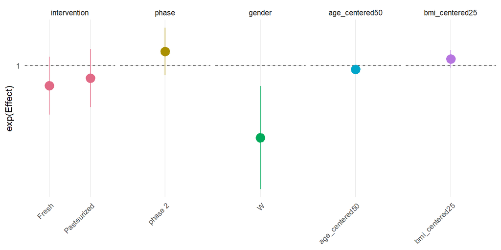

```r
APCtools::plot_linearEffects(m_propionic_acid)
```

```r
# save the interaction models for later use for visualization
m_propionic_acid_sexInt            <- outputList_propionic_acid$model_gamma_sexInt
m_propionic_acid_sexInt_changedRef <- outputList_propionic_acid$model_gamma_sexInt_changedRef
m_propionic_acid_ageInt            <- outputList_propionic_acid$model_gamma_ageInt
m_propionic_acid_ageInt_changedRef <- outputList_propionic_acid$model_gamma_ageInt_changedRef
m_propionic_acid_bmiInt            <- outputList_propionic_acid$model_gamma_bmiInt
m_propionic_acid_bmiInt_changedRef <- outputList_propionic_acid$model_gamma_bmiInt_changedRef
m_propionic_acid_fibInt            <- outputList_propionic_acid$model_gamma_fibInt
m_propionic_acid_fibInt_changedRef <- outputList_propionic_acid$model_gamma_fibInt_changedRef
m_propionic_acid_divInt            <- outputList_propionic_acid$model_gamma_divInt
m_propionic_acid_divInt_changedRef <- outputList_propionic_acid$model_gamma_divInt_changedRef
```

# SCRF - Valeric acid

## Sensitivity analysis results

All below results were estimated on the observed data, without specific outlier exclusion / handling. To check the influence of outliers on the results, the below models were re-estimated on the dataset in which outliers (= points above the threshold ‘mean + 3*sd’) were trimmed to the treshold ’mean + 3*sd’. These sensitivity results are not comprised in this document. The results based on the trimmed data were not substantially different from the original results.

```r
# # trim outliers to mean + 3*sd
# upper_threshold <- median(dat$stool_valericAcid) + 3*sd(dat$stool_valericAcid)
#
# dat <- dat %>%
#   mutate(stool_valericAcid_trimmed = case_when(stool_valericAcid < upper_threshold ~ stool_valericAcid,
#                                                TRUE                                ~ upper_threshold))
# dat_model <- dat_model %>%
#   mutate(stool_valericAcid_trimmed = case_when(stool_valericAcid < upper_threshold ~ stool_valericAcid,
#                                                TRUE                                ~ upper_threshold))
```

## Description

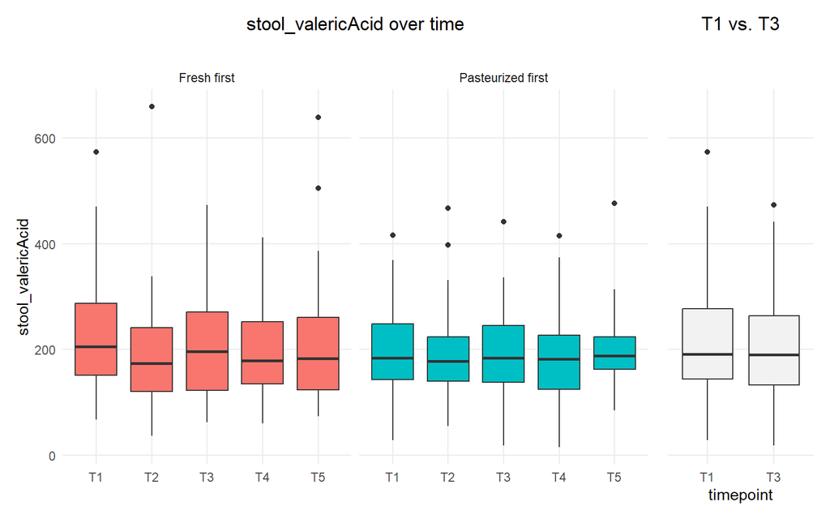

```r
plot_variable(dat, "stool_valericAcid", cut_extremeValues = FALSE)
```

## Model comparison

Share of deviance explained (including p-values for testing the respective interaction model against the model without interaction):

```r
outputList_valeric_acid <- compare_models("stool_valericAcid")

outputList_valeric_acid$tab_explainedDeviances %>% kable() %>% kable_styling()
```

| Model | Gaussian | Gaussian (log trafo) | Gamma |
| --- | --- | --- | --- |
| Raw intervention effect | 51.2% | 53.2% | 48.7% |
| Intervention effect by gender | 51.6% (p = 0.4177) | 53.9% (p = 0.1842) | 49.6% (p = 0.0904) |
| Intervention effect by age group | 51.7% (p = 0.3362) | 53.5% (p = 0.5639) | 48.8% (p = 0.7225) |
| Intervention effect by BMI group | 51.5% (p = 0.4131) | 53.5% (p = 0.4017) | 49.1% (p = 0.3084) |
| Intervention effect by fiber group | 51.3% (p = 0.9243) | 53.4% (p = 0.6915) | 49% (p = 0.5525) |
| Intervention effect by baseline diversity | 51.2% (p = 0.9999) | 53.1% (p = 0.9999) | 48.7% (p = 0.9999) |

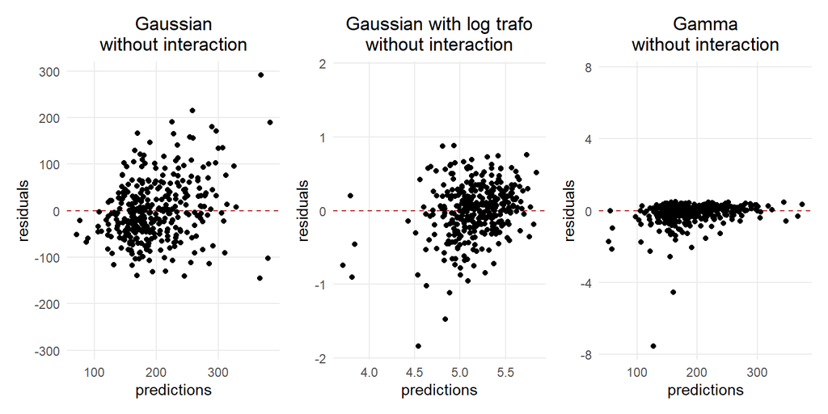

```r
outputList_valeric_acid$gg_residuals
```

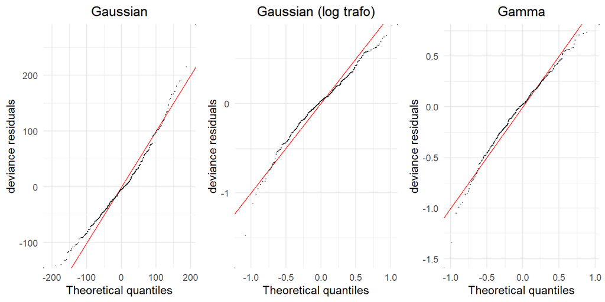

```r
mgcViz::gridPrint(outputList_valeric_acid$qq_gaussian, outputList_valeric_acid$qq_gaussianLog, outputList_valeric_acid$qq_gamma, nrow = 1)
```

## Final model (Gaussian)

##### Estimated effects

```r
m_valeric_acid        <- outputList_valeric_acid$model_gaussian

APCtools:::extract_summary_linearEffects(m_valeric_acid) %>%
  mutate(pvalue       = case_when(param == "(Intercept)" ~ "-",
                                  TRUE                   ~ pvalue %>% round(4) %>% as.character()),
         across(!contains("param") & !contains("pvalue"), function(x) { round(x, 3) })) %>%
  select(!contains("pvalue"), pvalue) %>%
  kable() %>%
  kable_styling()
```

| param | coef | se | CI_lower | CI_upper | pvalue |
| --- | --- | --- | --- | --- | --- |
| (Intercept) | 200.274 | 13.007 | 174.780 | 225.769 | - |
| interventionFresh | -15.173 | 9.645 | -34.078 | 3.732 | 0.1169 |
| interventionPasteurized | -13.345 | 9.683 | -32.324 | 5.634 | 0.1693 |
| phasephase 2 | -3.377 | 7.931 | -18.922 | 12.168 | 0.6706 |
| genderW | 9.825 | 15.983 | -21.500 | 41.150 | 0.5392 |
| age_centered50 | -0.847 | 0.550 | -1.925 | 0.231 | 0.1249 |
| bmi_centered25 | 3.778 | 2.739 | -1.592 | 9.147 | 0.169 |

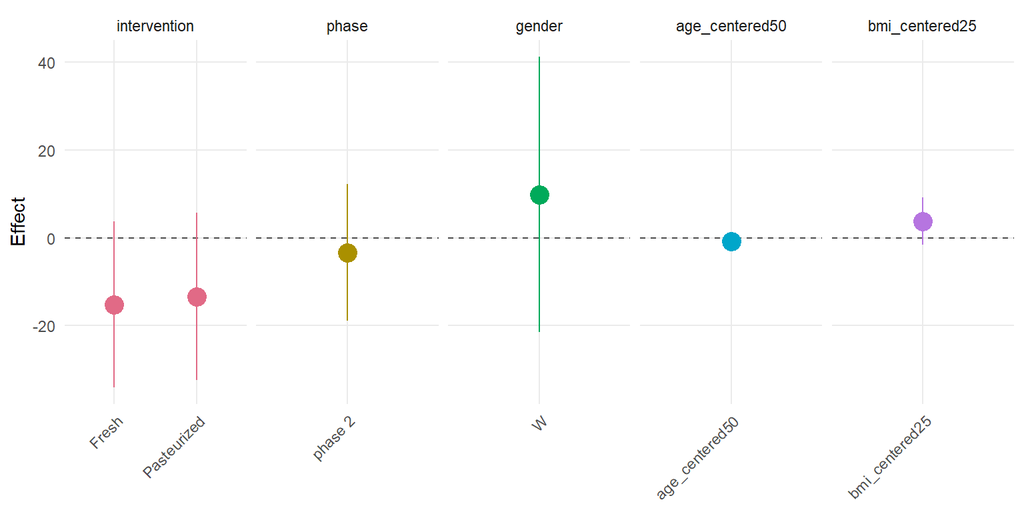

```r
APCtools::plot_linearEffects(m_valeric_acid)
```

```r
# save the interaction models for later use for visualization
m_valeric_acid_sexInt            <- outputList_valeric_acid$model_gaussian_sexInt
m_valeric_acid_sexInt_changedRef <- outputList_valeric_acid$model_gaussian_sexInt_changedRef
m_valeric_acid_ageInt            <- outputList_valeric_acid$model_gaussian_ageInt
m_valeric_acid_ageInt_changedRef <- outputList_valeric_acid$model_gaussian_ageInt_changedRef
m_valeric_acid_bmiInt            <- outputList_valeric_acid$model_gaussian_bmiInt
m_valeric_acid_bmiInt_changedRef <- outputList_valeric_acid$model_gaussian_bmiInt_changedRef
m_valeric_acid_fibInt            <- outputList_valeric_acid$model_gaussian_fibInt
m_valeric_acid_fibInt_changedRef <- outputList_valeric_acid$model_gaussian_fibInt_changedRef
m_valeric_acid_divInt            <- outputList_valeric_acid$model_gaussian_divInt
m_valeric_acid_divInt_changedRef <- outputList_valeric_acid$model_gaussian_divInt_changedRef
```

# Overview table of all models

```r
# create a joint vector of all variables
model_names <- c(SCFA_markers, BCFA_markers)
# create a model list
model_list <- list("Acetic acid (Stool)"          = m_acetic_acid,
                   "Propionic acid (Stool)"       = m_propionic_acid,
                   "Butyric acid (Stool)"         = m_butyric_acid,
                   "Valeric acid (Stool)"         = m_valeric_acid,
                   "Hexanoic acid (Stool)"        = m_hexanoic_acid,
                   "Iso-butyric acid (Stool)"     = m_isobutyric_acid,
                   "Iso-valeric acid (Stool)"     = m_isovaleric_acid,
                   "2-Methylbutyric acid (Stool)" = m_methylbutyric_acid2)
model_sexInt_list <- list("Acetic acid (Stool)"          = list(m_acetic_acid_sexInt, m_acetic_acid_sexInt_changedRef),
                          "Propionic acid (Stool)"       = list(m_propionic_acid_sexInt, m_propionic_acid_sexInt_changedRef),
                          "Butyric acid (Stool)"         = list(m_butyric_acid_sexInt, m_butyric_acid_sexInt_changedRef),
                          "Valeric acid (Stool)"         = list(m_valeric_acid_sexInt, m_valeric_acid_sexInt_changedRef),
                          "Hexanoic acid (Stool)"        = list(m_hexanoic_acid_sexInt, m_hexanoic_acid_sexInt_changedRef),
                          "Iso-butyric acid (Stool)"     = list(m_isobutyric_acid_sexInt, m_isobutyric_acid_sexInt_changedRef),
                          "Iso-valeric acid (Stool)"     = list(m_isovaleric_acid_sexInt, m_isovaleric_acid_sexInt_changedRef),
                          "2-Methylbutyric acid (Stool)" = list(m_methylbutyric_acid2_sexInt, m_methylbutyric_acid2_sexInt_changedRef))
model_ageInt_list <- list("Acetic acid (Stool)"          = list(m_acetic_acid_ageInt, m_acetic_acid_ageInt_changedRef),
                          "Propionic acid (Stool)"       = list(m_propionic_acid_ageInt, m_propionic_acid_ageInt_changedRef),
                          "Butyric acid (Stool)"         = list(m_butyric_acid_ageInt, m_butyric_acid_ageInt_changedRef),
                          "Valeric acid (Stool)"         = list(m_valeric_acid_ageInt, m_valeric_acid_ageInt_changedRef),
                          "Hexanoic acid (Stool)"        = list(m_hexanoic_acid_ageInt, m_hexanoic_acid_ageInt_changedRef),
                          "Iso-butyric acid (Stool)"     = list(m_isobutyric_acid_ageInt, m_isobutyric_acid_ageInt_changedRef),
                          "Iso-valeric acid (Stool)"     = list(m_isovaleric_acid_ageInt, m_isovaleric_acid_ageInt_changedRef),
                          "2-Methylbutyric acid (Stool)" = list(m_methylbutyric_acid2_ageInt, m_methylbutyric_acid2_ageInt_changedRef))
model_bmiInt_list <- list("Acetic acid (Stool)"          = list(m_acetic_acid_bmiInt, m_acetic_acid_bmiInt_changedRef),
                          "Propionic acid (Stool)"       = list(m_propionic_acid_bmiInt, m_propionic_acid_bmiInt_changedRef),
                          "Butyric acid (Stool)"         = list(m_butyric_acid_bmiInt, m_butyric_acid_bmiInt_changedRef),
                          "Valeric acid (Stool)"         = list(m_valeric_acid_bmiInt, m_valeric_acid_bmiInt_changedRef),
                          "Hexanoic acid (Stool)"        = list(m_hexanoic_acid_bmiInt, m_hexanoic_acid_bmiInt_changedRef),
                          "Iso-butyric acid (Stool)"     = list(m_isobutyric_acid_bmiInt, m_isobutyric_acid_bmiInt_changedRef),
                          "Iso-valeric acid (Stool)"     = list(m_isovaleric_acid_bmiInt, m_isovaleric_acid_bmiInt_changedRef),
                          "2-Methylbutyric acid (Stool)" = list(m_methylbutyric_acid2_bmiInt, m_methylbutyric_acid2_bmiInt_changedRef))
model_fibInt_list <- list("Acetic acid (Stool)"          = list(m_acetic_acid_fibInt, m_acetic_acid_fibInt_changedRef),
                          "Propionic acid (Stool)"       = list(m_propionic_acid_fibInt, m_propionic_acid_fibInt_changedRef),
                          "Butyric acid (Stool)"         = list(m_butyric_acid_fibInt, m_butyric_acid_fibInt_changedRef),
                          "Valeric acid (Stool)"         = list(m_valeric_acid_fibInt, m_valeric_acid_fibInt_changedRef),
                          "Hexanoic acid (Stool)"        = list(m_hexanoic_acid_fibInt, m_hexanoic_acid_fibInt_changedRef),
                          "Iso-butyric acid (Stool)"     = list(m_isobutyric_acid_fibInt, m_isobutyric_acid_fibInt_changedRef),
                          "Iso-valeric acid (Stool)"     = list(m_isovaleric_acid_fibInt, m_isovaleric_acid_fibInt_changedRef),
                          "2-Methylbutyric acid (Stool)" = list(m_methylbutyric_acid2_fibInt, m_methylbutyric_acid2_fibInt_changedRef))
model_divInt_list <- list("Acetic acid (Stool)"          = list(m_acetic_acid_divInt, m_acetic_acid_divInt_changedRef),
                          "Propionic acid (Stool)"       = list(m_propionic_acid_divInt, m_propionic_acid_divInt_changedRef),
                          "Butyric acid (Stool)"         = list(m_butyric_acid_divInt, m_butyric_acid_divInt_changedRef),
                          "Valeric acid (Stool)"         = list(m_valeric_acid_divInt, m_valeric_acid_divInt_changedRef),
                          "Hexanoic acid (Stool)"        = list(m_hexanoic_acid_divInt, m_hexanoic_acid_divInt_changedRef),
                          "Iso-butyric acid (Stool)"     = list(m_isobutyric_acid_divInt, m_isobutyric_acid_divInt_changedRef),
                          "Iso-valeric acid (Stool)"     = list(m_isovaleric_acid_divInt, m_isovaleric_acid_divInt_changedRef),
                          "2-Methylbutyric acid (Stool)" = list(m_methylbutyric_acid2_divInt, m_methylbutyric_acid2_divInt_changedRef))
# create a lookup list for the final model type
modelType_list <- list("Acetic acid (Stool)"          = "Gamma",
                       "Propionic acid (Stool)"       = "Gamma",
                       "Butyric acid (Stool)"         = "Gamma",
                       "Valeric acid (Stool)"         = "Gaussian",
                       "Hexanoic acid (Stool)"        = "Gaussian",
                       "Iso-butyric acid (Stool)"     = "Gamma",
                       "Iso-valeric acid (Stool)"     = "Gamma",
                       "2-Methylbutyric acid (Stool)" = "log Gaussian")


# overview table
data.frame(Model              = names(model_list),
           Model_type         = unlist(modelType_list, use.names = FALSE),
           Deviance_explained = sapply(model_list, function(x) { paste0(round(100 * summary(x)$dev.expl, 1), "%") }, USE.NAMES = FALSE) %>% unname()) %>%
  kable() %>%
  kable_styling()
```

| Model | Model_type | Deviance_explained |
| --- | --- | --- |
| Acetic acid (Stool) | Gamma | 52.3% |
| Propionic acid (Stool) | Gamma | 61.2% |
| Butyric acid (Stool) | Gamma | 51.4% |
| Valeric acid (Stool) | Gaussian | 51.5% |
| Hexanoic acid (Stool) | Gaussian | 67.7% |
| Iso-butyric acid (Stool) | Gamma | 50.4% |
| Iso-valeric acid (Stool) | Gamma | 54.4% |
| 2-Methylbutyric acid (Stool) | log Gaussian | 58% |

# Joint plot of all effects

```r
# create a results table with all effects
modelResults_list <- lapply(names(model_names), function(x) {

  variable   <- model_names[x] %>% unname()
  model      <- model_list[[x]]
  model_type <- modelType_list[[x]]

  log_wasApplied <- (model_type %in% c("Gamma", "log Gaussian"))

  results_dat <- summary(model)$p.table %>%
    as.data.frame() %>%
    mutate(parameter   = row.names(.),
           param_group = case_when(parameter %in% c("interventionFresh", "interventionPasteurized") ~ "intervention",
                                   grepl("carry_over", parameter)                                   ~ "carry-over",
                                   grepl("phase", parameter)                                        ~ "phase",
                                   grepl("gender", parameter)                                       ~ "gender",
                                   grepl("bmi", parameter)                                          ~ "BMI",
                                   grepl("age", parameter)                                          ~ "age",
                                   grepl("dailyFiber",  parameter)                                  ~ "daily fiber",
                                   grepl("baselineDiv", parameter)                                  ~ "baseline diversity",
                                   TRUE                                                             ~ parameter)) %>%
    dplyr::rename(estimate   = "Estimate",
                  se         = "Std. Error",
                  pvalue     = "Pr(>|t|)") %>%
    mutate(model      = x,
           model_type = model_type,
           CI_lower   = estimate - qnorm(0.975) * se,
           CI_upper   = estimate + qnorm(0.975) * se)

  if (!log_wasApplied) { # standardize the effects by the standard deviation of the response variable
    results_dat <- results_dat %>%
      mutate(y_sd = sd(dat_model[[variable]], na.rm = TRUE),
             estimate_standardized = estimate / y_sd,
             se_standardized       = se / y_sd,
             CI_lower_standardized = estimate_standardized - qnorm(0.975) * se_standardized,
             CI_upper_standardized = estimate_standardized + qnorm(0.975) * se_standardized)

  } else { # exponentiate the effects
    results_dat <- results_dat %>%
      mutate(exp_estimate = exp(estimate),
             exp_CIlower  = exp(CI_lower),
             exp_CIupper  = exp(CI_upper),
             y_sd = NA)
  }

  results_dat <- results_dat %>%
    select(model, model_type, param_group, parameter, y_sd, estimate, CI_lower, CI_upper, pvalue, contains("standardized"), contains("exp"))
  row.names(results_dat) <- NULL

  return(results_dat)
})
results_dat <- modelResults_list %>% bind_rows() %>%
  mutate(model       = factor(model, levels = names(model_names)),
         model_group = case_when(model %in% names(SCFA_markers) ~ "scfa",
                                 TRUE                           ~ "bcfa"),
         model_group = factor(model_group, levels = names(col_vector)))
```